# Projet STA203

Salomé Darblade-Mallet, Lore Lafuente, Mathilda Alhamadah

2024-11-01

# 1. Préparation des données

On commence par importer les packages nécessaires :

```r
library(dplyr)
library(survival)
library(VIM)
library(gtsummary)
library(boot)
library(broom)
```

Importation des données :

```r
medidemence <- read.delim("medidemence.txt", header = TRUE)
data <- medidemence
```

On convertit le type des données selon ce qui est préconisé par l’énoncé :

```r
summary(data)
```

```
##     NUM_PAT          Alcool          HOLIV1_C        HOLIV1_A
##  Min.   :10003   Min.   :  0.00   Min.   :1.000   Min.   :1.000
##  1st Qu.:10645   1st Qu.:  0.00   1st Qu.:2.000   1st Qu.:1.000
##  Median :11346   Median :  8.00   Median :4.000   Median :2.000
##  Mean   :11327   Mean   : 12.61   Mean   :3.238   Mean   :2.314
##  3rd Qu.:12004   3rd Qu.: 19.20   3rd Qu.:4.000   3rd Qu.:4.000
##  Max.   :12656   Max.   :108.80   Max.   :4.000   Max.   :4.000
##
##  NON_REFINED_CEREALS    POTATOES          FRUITS        VEGETABLES
##  Min.   : 0.00       Min.   : 0.000   Min.   : 0.00   Min.   : 0.00
##  1st Qu.:19.00       1st Qu.: 1.000   1st Qu.: 9.00   1st Qu.:14.00
##  Median :23.00       Median : 2.000   Median :14.00   Median :19.00
##  Mean   :22.05       Mean   : 2.625   Mean   :13.54   Mean   :19.33
##  3rd Qu.:25.50       3rd Qu.: 4.000   3rd Qu.:17.00   3rd Qu.:24.00
##  Max.   :51.00       Max.   :10.000   Max.   :66.00   Max.   :47.00
##
##     LEGUMES          SEAFOOD           MEATS           POULTRY
##  Min.   :0.0000   Min.   : 0.000   Min.   : 0.000   Min.   :0.000
##  1st Qu.:0.2500   1st Qu.: 1.500   1st Qu.: 4.000   1st Qu.:1.000
##  Median :0.5000   Median : 2.500   Median : 6.000   Median :1.500
##  Mean   :0.6137   Mean   : 2.885   Mean   : 6.443   Mean   :1.819
##  3rd Qu.:1.0000   3rd Qu.: 4.000   3rd Qu.: 8.000   3rd Qu.:2.500
##  Max.   :8.0000   Max.   :12.000   Max.   :25.000   Max.   :8.000
##
##  DAIRY_PRODUCTS      SEXE          etudeb0          apoE4
##  Min.   : 0.0   Min.   :1.000   Min.   :1.000   Min.   :0.0000
##  1st Qu.:14.0   1st Qu.:1.000   1st Qu.:1.000   1st Qu.:0.0000
##  Median :17.0   Median :2.000   Median :2.000   Median :0.0000
##  Mean   :18.2   Mean   :1.633   Mean   :2.251   Mean   :0.1793
##  3rd Qu.:23.0   3rd Qu.:2.000   3rd Qu.:3.000   3rd Qu.:0.0000
##  Max.   :63.0   Max.   :2.000   Max.   :4.000   Max.   :1.0000
##                                 NA's   :7       NA's   :134
##       age1            age2          agedem4           AGE4
##  Min.   :67.69   Min.   :69.71   Min.   :68.88   Min.   :73.04
##  1st Qu.:71.91   1st Qu.:73.89   1st Qu.:76.25   1st Qu.:76.61
##  Median :75.40   Median :77.34   Median :79.62   Median :79.87
##  Mean   :75.93   Mean   :77.89   Mean   :80.10   Mean   :80.45
##  3rd Qu.:79.61   3rd Qu.:81.56   3rd Qu.:83.62   3rd Qu.:83.82
##  Max.   :94.91   Max.   :96.96   Max.   :95.93   Max.   :94.71
##                  NA's   :144                     NA's   :257
```

[output cut: 9 more lines]

```
##  Min.   :0.0000   Min.   :68.88   Min.   :75.59   Min.   :0.0000
##  1st Qu.:0.0000   1st Qu.:78.32   1st Qu.:79.15   1st Qu.:0.0000
##  Median :0.0000   Median :81.57   Median :82.14   Median :1.0000
##  Mean   :0.0654   Mean   :81.88   Mean   :82.87   Mean   :0.5077
##  3rd Qu.:0.0000   3rd Qu.:85.12   3rd Qu.:86.13   3rd Qu.:1.0000
##  Max.   :1.0000   Max.   :97.17   Max.   :97.17   Max.   :1.0000
##  NA's   :428                      NA's   :428
##       Acal
##  Min.   :0.0000
##  1st Qu.:0.0000
##  Median :1.0000
##  Mean   :0.6708
##  3rd Qu.:1.0000
##  Max.   :1.0000
##
```

```r
#convert factor variables
for (var in c("HOLIV1_C", "HOLIV1_A", "SEXE", "etudeb0", "apoE4", "DIABETE1", "Acal", "medic", "DEMS2", "DEMS4", "DEMS5")) {
  data[[var]] <- as.factor(data[[var]])
}

#check type
for (var in c("HOLIV1_C", "HOLIV1_A", "SEXE", "etudeb0", "apoE4", "DIABETE1", "Acal", "medic", "DEMS2", "DEMS4", "DEMS5")) {
  print(class(data[[var]]))
}
```

```
## [1] "factor"
## [1] "factor"
## [1] "factor"
## [1] "factor"
## [1] "factor"
## [1] "factor"
## [1] "factor"
## [1] "factor"
## [1] "factor"
## [1] "factor"
## [1] "factor"
```

```r
str(data) #tous les types des var sont bons
```

```
## 'data.frame':    1361 obs. of  29 variables:
##  $ NUM_PAT            : int  10003 10005 10010 10011 10015 10016 10019 10022 10023 10024 ...
##  $ Alcool             : num  0 40 6.96 16 9.6 52 0 0 3.84 0 ...
##  $ HOLIV1_C           : Factor w/ 4 levels "1","2","3","4": 4 4 1 4 1 4 2 4 2 1 ...
##  $ HOLIV1_A           : Factor w/ 4 levels "1","2","3","4": 1 4 3 1 1 1 1 4 2 1 ...
##  $ NON_REFINED_CEREALS: num  27 15.5 23 34 14 ...
##  $ POTATOES           : num  2 3 0.5 9 0 2 2 2 1 1 ...
##  $ FRUITS             : num  0 4 26 11 18 14 5 10 14.5 7 ...
##  $ VEGETABLES         : num  16 18 26 30 21 21 9 21.5 17 18 ...
##  $ LEGUMES            : num  2 1 1 0.5 0.5 0.5 0 1 0.75 0.25 ...
##  $ SEAFOOD            : num  4 3 5 5 4.25 3 6 2.25 2.5 8 ...
##  $ MEATS              : num  11 6 3 5 5 6 3.5 3 4.25 4 ...
##  $ POULTRY            : num  2 3 3 3 0 3 0.5 1 1 2 ...
##  $ DAIRY_PRODUCTS     : num  23 7 18 26 14 35 25 9 14 14 ...
##  $ SEXE               : Factor w/ 2 levels "1","2": 2 2 2 2 2 2 2 2 2 2 ...
##  $ etudeb0            : Factor w/ 4 levels "1","2","3","4": 1 2 1 1 1 2 3 2 2 1 ...
##  $ apoE4              : Factor w/ 2 levels "0","1": 1 1 1 1 2 2 2 1 NA NA ...
##  $ age1               : num  74.6 77.1 81.5 67.7 76.4 ...
##  $ age2               : num  76.6 NA 83.7 69.7 78.8 ...
##  $ agedem4            : num  79.8 77.1 86.8 73.1 78.8 ...
##  $ AGE4               : num  79.8 NA 86.8 73.1 NA ...
##  $ DEMS2              : Factor w/ 2 levels "0","1": 1 NA 1 1 1 1 1 1 1 1 ...
##  $ DEMS4              : Factor w/ 2 levels "0","1": 1 NA 1 1 NA 1 1 1 1 2 ...
##  $ agedem2            : num  76.6 77.1 83.7 69.7 78.8 ...
##  $ DIABETE1           : Factor w/ 2 levels "0","1": 1 1 1 1 1 1 1 1 1 1 ...
##  $ DEMS5              : Factor w/ 2 levels "0","1": 1 2 2 1 1 2 1 NA 1 1 ...
##  $ agedem5            : num  82.3 81.1 88 75.6 84.5 ...
##  $ age5               : num  82.3 85.2 89.3 75.6 84.5 ...
##  $ medic              : Factor w/ 2 levels "0","1": 2 2 2 2 1 2 2 2 1 2 ...
##  $ Acal               : Factor w/ 2 levels "0","1": 2 2 1 1 2 1 2 1 2 2 ...
```

```r
rm(var)
```

# 2. Construction du score MeDi

## a) Comment construire le score MeDi

Les variables à utiliser :

→ Article Panagiotakos :

- Céréales non raffinées (pain complet, pâtes complètes, riz brun, etc.)
- Fruits
- Légumes
- Légumineuses
- Pommes de terre
- Poisson
- Viande rouge et produits dérivés (inversé pour les aliments éloignés du régime méditerranéen)
- Volaille (évaluée à l’inverse aussi)
- Produits laitiers gras (fromage, yaourt, lait – aussi évalué à l’inverse)

→ Article Feart :

- Mêmes variables que Panagiotakos
- Alcool
- Ratio des acides gras monoinsaturés sur les acides gras saturés

→ Les variables liées à la démence sur lesquelles ajuster le modèle :

- Âge
- Sexe
- Niveau d’éducation
- Statut marital
- Consommation énergétique totale
- Exercice physique
- Prise de 5 médicaments ou plus par jour
- Génotype ApoE4
- Symptomatologie dépressive (évaluée par l’échelle CES-D)
- Facteurs de risque cardiovasculaires (indice de masse corporelle, hypertension, diabète, hypercholestérolémie, tabagisme)
- Antécédents d’AVC

## b) Recoder les variables de nutrition pour le score MeDi

On compte l’ensemble des données manquantes. Il y en a 1801 :

```r
sum(is.na(data))
```

```
## [1] 1801
```

Puis on compte les données manquantes dans les variables de nutrition :

```r
sum(is.na(
  data %>%
    select (NON_REFINED_CEREALS, POTATOES, POULTRY, LEGUMES, VEGETABLES, FRUITS, MEATS, SEAFOOD, DAIRY_PRODUCTS, Alcool, HOLIV1_C, HOLIV1_A)
))
```

```
## [1] 0
```

On voit qu’il n’y a aucune donnée manquante sur les informations en lien avec la nutrition. Les seules données manquantes à gérer se trouvent donc dans les variables sociodémographiques.

On créé le score MeDi dans le jeu de données initial data :

```r
data <- data %>%  #OK
  mutate(medi_cereals = case_when(
    NON_REFINED_CEREALS == 0 ~ 0,
    NON_REFINED_CEREALS > 0 & NON_REFINED_CEREALS < 7 ~ 1,
    NON_REFINED_CEREALS >=7 & NON_REFINED_CEREALS < 13 ~ 2,
    NON_REFINED_CEREALS >=13 & NON_REFINED_CEREALS < 19 ~ 3,
    NON_REFINED_CEREALS >=19 & NON_REFINED_CEREALS < 32 ~ 4,
    NON_REFINED_CEREALS >= 32 ~ 5,
    TRUE ~ NA),

    medi_potatoes = case_when(
    POTATOES == 0 ~ 0,
    POTATOES > 0 & POTATOES < 4 ~ 1,
    POTATOES >= 4 & POTATOES < 8 ~ 2,
    POTATOES >= 8 & POTATOES < 12 ~ 3,
    POTATOES >=12 & POTATOES < 18 ~ 4,
    POTATOES >= 18 ~ 5,
    TRUE ~ NA),

    medi_fruits = case_when(
    FRUITS == 0 ~ 0,
    FRUITS > 0 & FRUITS < 4 ~ 1,
    FRUITS >=4 & FRUITS < 8 ~ 2,
    FRUITS >=8 & FRUITS < 15 ~ 3,
    FRUITS >=15 & FRUITS < 21 ~ 4,
    FRUITS >= 21 ~ 5,
    TRUE ~ NA),

    medi_vegetables = case_when(
    VEGETABLES == 0 ~ 0,
    VEGETABLES > 0 & VEGETABLES < 6 ~ 1,
    VEGETABLES >=6 & VEGETABLES < 12 ~ 2,
    VEGETABLES >=12 & VEGETABLES < 20 ~ 3,
    VEGETABLES >=20 & VEGETABLES < 32 ~ 4,
    VEGETABLES >= 32 ~ 5,
    TRUE ~ NA),

    medi_legumes = case_when(
    LEGUMES == 0 ~ 0,
    LEGUMES > 0 & LEGUMES < 1 ~ 1,
    LEGUMES >=1 & LEGUMES < 2 ~ 2,
    LEGUMES >=2 & LEGUMES < 4 ~ 3,
    LEGUMES >=4 & LEGUMES < 6 ~ 4,
    LEGUMES >= 6 ~ 5,
    TRUE ~ NA),

    medi_seafood = case_when(
    SEAFOOD == 0 ~ 0,
    SEAFOOD > 0 & SEAFOOD < 1 ~ 1,
    SEAFOOD >=1 & SEAFOOD < 2 ~ 2,
    SEAFOOD >=2 & SEAFOOD < 4 ~ 3,
    SEAFOOD >=4 & SEAFOOD < 6 ~ 4,
    SEAFOOD >= 6 ~ 5,
    TRUE ~ NA),

    medi_meat = case_when(
    MEATS >= 10 ~ 0,
    MEATS >=7 & MEATS < 10 ~ 1,
    MEATS >=5 & MEATS < 7 ~ 2,
    MEATS >=3 & MEATS < 5 ~ 3,
    MEATS > 1 & MEATS < 3 ~ 4,
    MEATS <= 1 ~ 5,
    TRUE ~ NA),

    medi_poultry = case_when(
    POULTRY >= 10 ~ 0,
    POULTRY >= 8 & POULTRY < 10 ~ 1,
    POULTRY >= 6 & POULTRY < 8 ~ 2,
    POULTRY >= 5 & POULTRY < 6 ~ 3,   #attention pas comme dans l'article : limite
    POULTRY > 3 & POULTRY < 5 ~ 4,  #dans l'article c'est 4 mais ça vire un indiv
    POULTRY <= 3 ~ 5,
    TRUE ~ NA),

    medi_dairy_products = case_when(
    DAIRY_PRODUCTS >= 30 ~ 0,
    DAIRY_PRODUCTS >= 28 & DAIRY_PRODUCTS < 30 ~ 1,
    DAIRY_PRODUCTS >= 20 & DAIRY_PRODUCTS < 28 ~ 2,
    DAIRY_PRODUCTS >= 15 & DAIRY_PRODUCTS < 20 ~ 3,
    DAIRY_PRODUCTS > 10 & DAIRY_PRODUCTS < 15 ~ 4,
    DAIRY_PRODUCTS <= 10 ~ 5,
    TRUE ~ NA),

    medi_alcool = case_when(         #attention pas comme dans l'article : limite
    Alcool == 0 | Alcool > 700 ~ 0,
    Alcool > 600 & Alcool <= 700 ~ 1,
    Alcool > 500 & Alcool <= 600 ~ 2,
    Alcool > 400 & Alcool <= 500 ~ 3,
    Alcool > 300 & Alcool <= 400 ~ 4,
    Alcool <= 300 & Alcool > 0 ~ 5,
    TRUE ~ NA)
           )

#nouvelle variable huile d'olive totale
data$HOLIV1_C <- as.numeric(data$HOLIV1_C)
data$HOLIV1_A <- as.numeric(data$HOLIV1_A)
class(data$HOLIV1_C)
```

```
## [1] "numeric"
```

```r
data$holivtot <- data$HOLIV1_A + data$HOLIV1_C
head(data$holivtot)
```

```
## [1] 5 8 4 5 2 5
```

```r
data <- data %>%
  mutate(medi_holiv = case_when(
    holivtot == 8 ~ 0,
    holivtot == 7 ~ 1,
    holivtot == 6 ~ 2,
    holivtot == 5 ~ 3,
    holivtot == 4 ~ 4,
    holivtot <= 3 ~ 5,
    TRUE ~ NA))

tabverif<- (data %>% select (holivtot, medi_holiv)) #check

#remettre huile d'olive assaissonnement et cuisson en facteur
data$HOLIV1_C <- as.factor(data$HOLIV1_C)
data$HOLIV1_A <- as.factor(data$HOLIV1_A)
class(data$HOLIV1_C)
```

```
## [1] "factor"
```

```r
rm(tabverif)
```

On remarque que les quantités bues d’alcool sont très faibles comparées à l’échelle tirée de l’article de Panagiotakos : les individus sont tous à 0 ou à moins de 300 mL de boissons alcoolisées par jour. Ils se situent donc tous dans les classes du score MeDi de 0 mL d’alcool par jour ou de moins de 300mL d’alcool par jour.

On fait un score total pour l’huile d’olive en sommant les scores de la cuisson et de l’assaisonnement. On prend ce score à l’inverse pour le score MeDi en associant au score de 8 (jamais en cuisson et jamais en assaisonnement) la valeur 0 (Jamais), puis aux score 7 6 5 4 et 3 respectivement les valeurs 1 2 3 et 4, et enfin en agrégeant les deux modalités de 2 et 3 (toujours/toujours et toujours/le plus souvent) à un score de 5 (tous les jours).

On vérifie les modalités et on voit que les unités utilisées étaient les bonnes et que les scores utilisés pour le MeDi semblent cohérents. Seules les pommes de terres et la volaille n’atteignent pas les bornes supérieures de la consommation, à savoir plus de 12 portions de pommes de terres par semaine et plus de 8 portions de volaille par semaine. Cela semble cohérent avec les habitudes de consommation d’une personne âgée classique.

## c) Construction du score MeDi

On utilise donc les variables ainsi recodées pour construire le score MeDi :

```r
data <- data %>%
  mutate(MeDi = medi_cereals + medi_potatoes + medi_fruits + medi_vegetables
         + medi_legumes + medi_seafood + medi_meat + medi_poultry
         + medi_dairy_products + medi_alcool + medi_holiv)

min(data$MeDi)
```

```
## [1] 13
```

```r
max(data$MeDi)
```

```
## [1] 45
```

```r
data[is.na(data$MeDi), ]
```

```
##  [1] NUM_PAT             Alcool              HOLIV1_C
##  [4] HOLIV1_A            NON_REFINED_CEREALS POTATOES
##  [7] FRUITS              VEGETABLES          LEGUMES
## [10] SEAFOOD             MEATS               POULTRY
## [13] DAIRY_PRODUCTS      SEXE                etudeb0
## [16] apoE4               age1                age2
## [19] agedem4             AGE4                DEMS2
## [22] DEMS4               agedem2             DIABETE1
## [25] DEMS5               agedem5             age5
## [28] medic               Acal                medi_cereals
## [31] medi_potatoes       medi_fruits         medi_vegetables
## [34] medi_legumes        medi_seafood        medi_meat
## [37] medi_poultry        medi_dairy_products medi_alcool
## [40] holivtot            medi_holiv          MeDi
## <0 lignes> (ou 'row.names' de longueur nulle)
```

## d) Représentation graphique de la distribution

Boxplot du score MeDi :

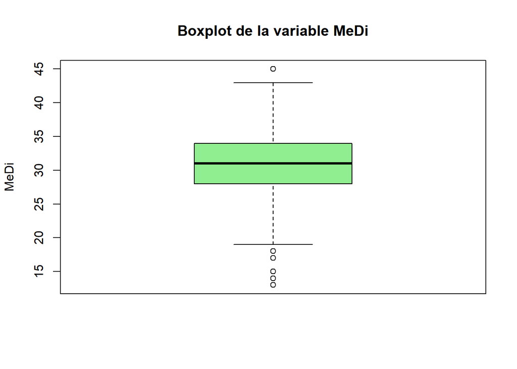

```r
# Créer un boxplot de la variable 'MeDi'
boxplot(data$MeDi,
        main="Boxplot de la variable MeDi",
        ylab="MeDi",
        col="lightgreen")
```

Histogramme avec la densité du score MeDi :

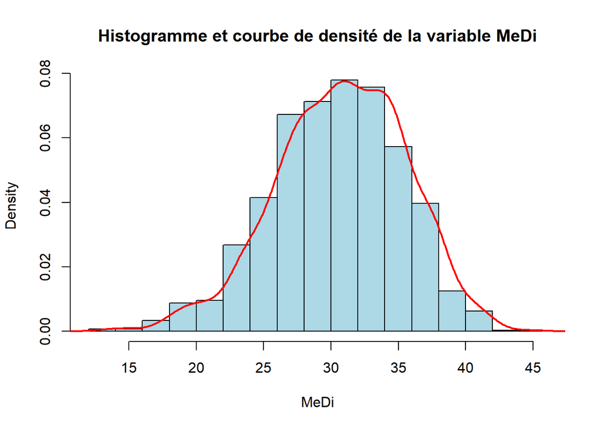

```r
# Combiner histogramme et courbe de densité pour 'MeDi'
hist(data$MeDi,
     freq=FALSE,
     main="Histogramme et courbe de densité de la variable MeDi",
     xlab="MeDi",
     col="lightblue",
     border="black")

# Ajouter la courbe de densité
lines(density(data$MeDi, na.rm=TRUE),
      col="red",
      lwd=2) # lwd ajuste l'épaisseur de la courbe
```

On catégorise le score MeDi en trois classes : score faible, score moyen et score fort d’adéquation au MeDi. C’est ce qui semble le plus pertinent pour avoir de la variabilité inter-classes et en même temps pouvoir identifier une relation dose-effet entre la démence et la catégorie de MeDi. C’est également par soucis d’interprétabilité des résultats que ce choix est fait.

Cependant, si on réalise ces classes en fonction de valeur fixes, les effectifs de chaque classe ne seront pas forcément du même ordre de grandeur : la classe ayant un score “moyen” sera surreprésentée en effectif parce que le score MeDi est distribué selon une loi qui semble normale. De plus, on n’identifie pas vraiment dans la littérature de valeur seuil que l’on pourrait utiliser pour couper en 3 classes. On utilise donc les terciles ce qui supprime le potentiel problème vis-à-vis de l’estimation du coefficient associé à une classe peu représentée :

```r
# Calcul des terciles de la variable 'MeDi'
terciles <- quantile(data$MeDi, probs = c(1/3, 2/3), na.rm = FALSE)

# Découper 'MeDi' en trois classes selon les terciles
data$MeDi_class <- cut(data$MeDi,
                       breaks = c(-Inf, terciles, Inf),
                       labels = c("Bas", "Moyen", "Haut"),
                       include.lowest = TRUE)

# Afficher les nouvelles classes
table(data$MeDi_class)
```

```
##
##   Bas Moyen  Haut
##   520   415   426
```

```r
rm(terciles)
```

On représente graphiquement les effectifs de chaque classe du score MeDi :

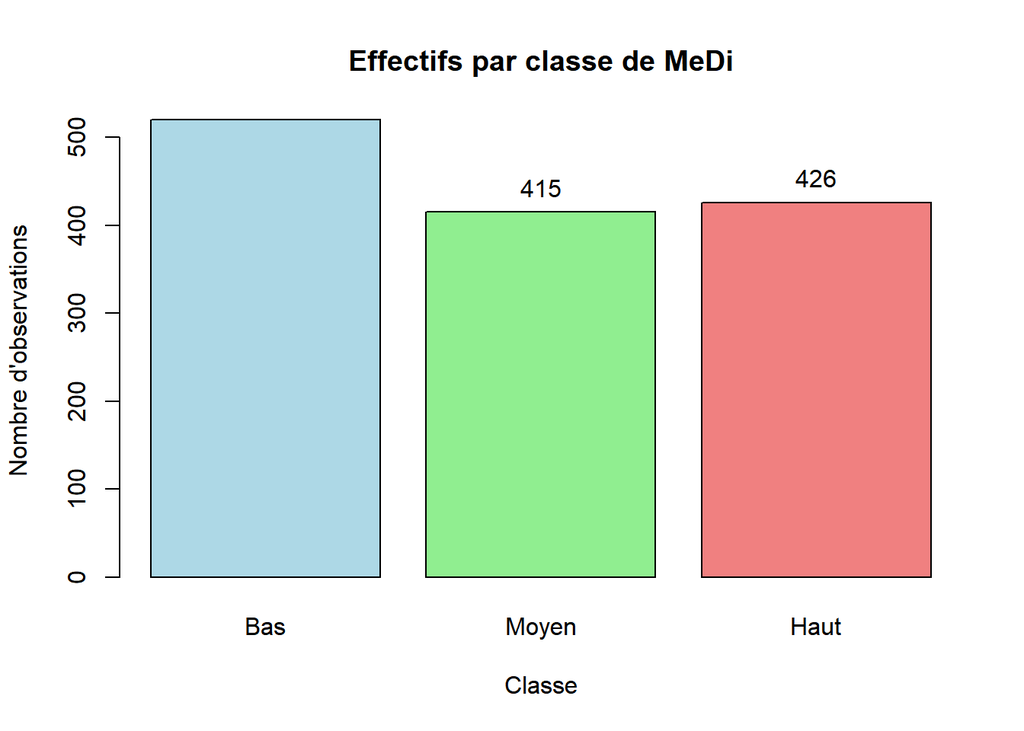

```r
effectifs <- table(data$MeDi_class)

par(mar = c(5, 4, 4, 2) + 0.1)

# Créer un barchart avec les nombres affichés au-dessus des barres
bp <- barplot(effectifs,
              main = "Effectifs par classe de MeDi",
              xlab = "Classe",
              ylab = "Nombre d'observations",
              col = c("lightblue", "lightgreen", "lightcoral"),
              border = "black")

# Ajouter les nombres au-dessus des barres
text(bp, effectifs + 1, labels = effectifs, pos = 3)
```

```r
rm(effectifs)
```

On identifie les bornes des classes en termes de score MeDi, et on vérifie que la variable a été correctement codée :

```r
# Calcul des terciles de la variable 'MeDi'
quantile(data$MeDi, probs = c(0, 1/3, 2/3, 1), na.rm = TRUE)
```

```
##        0% 33.33333% 66.66667%      100%
##        13        29        33        45
```

```r
# Check avec les données
data[data$MeDi %in% c(29, 33), c("MeDi", "MeDi_class")]
```

```
##      MeDi MeDi_class
## 16     29        Bas
## 18     33      Moyen
## 20     29        Bas
## 37     29        Bas
## 59     29        Bas
## 60     33      Moyen
## 68     29        Bas
## 69     33      Moyen
## 72     29        Bas
## 76     29        Bas
## 86     29        Bas
## 102    29        Bas
## 107    33      Moyen
## 113    29        Bas
```

[output cut: 171 more lines]

Donc nos classes de score MeDi sont :

- Bas : [13, 29]
- Moyen : ]29, 33]
- Haut : ]33, 45]

# 3. Ajout de variables utiles

## a) Variable indicatrice de la démence

Au lieu de 0 et 1 comme indiqué dans l’énoncé, les variables DEMS2, DEMS4 et DEMS5 sont codées 1 et 2 du fait des multiples conversions de facteurs en numériques et de numériques en facteurs. On les recode correctement, puis on créé une variable indicatrice de la démence :

```r
#Variables binaires en numérique
data$DEMS2 <- as.numeric(data$DEMS2)      #Attention ça passe en 1/2 du coup !
data$DEMS4 <- as.numeric(data$DEMS4)
data$DEMS5 <- as.numeric(data$DEMS5)
class(c(data$DEMS2, data$DEMS4, data$DEMS5))
```

```
## [1] "numeric"
```

```r
#Recoder en 0 1 plutôt que 1 2
data$DEMS2 <- data$DEMS2 -1
data$DEMS4 <- data$DEMS4 -1
data$DEMS5 <- data$DEMS5 -1
summary(data$DEMS2)
```

```
##    Min. 1st Qu.  Median    Mean 3rd Qu.    Max.    NA's
## 0.00000 0.00000 0.00000 0.01972 0.00000 1.00000     144
```

```r
summary(data$DEMS4)
```

```
##    Min. 1st Qu.  Median    Mean 3rd Qu.    Max.    NA's
## 0.00000 0.00000 0.00000 0.06159 0.00000 1.00000     257
```

```r
summary(data$DEMS5)
```

```
##    Min. 1st Qu.  Median    Mean 3rd Qu.    Max.    NA's
##  0.0000  0.0000  0.0000  0.0654  0.0000  1.0000     428
```

```r
#Créer la variable qui somme l'occurence de la démence
data <- data %>%
  mutate(dementia = rowSums(select(., DEMS2, DEMS4, DEMS5), na.rm = TRUE))
summary(data$dementia)
```

```
##    Min. 1st Qu.  Median    Mean 3rd Qu.    Max.
##  0.0000  0.0000  0.0000  0.1124  0.0000  1.0000
```

Cette variable est construite comme la somme par individu des démences incidentes. On se sert de cette variable pour vérifier de potentielles erreurs dans la base de données : le maximum est bien à 1, donc aucun sujet n’a été déclaré comme nouvellement dément au cours de deux suivis différents.

## b) Variable bac

On change la variable niveau d’études pour la recoder en 2 modalités seulement : cela permet d’avoir moins de modalités à intégrer au modèle, et de distinguer deux profils de niveau d’études plus clivants que les quatre initialement présents. La variable est nommée bac :

```r
data <- data %>%
  mutate(bac = case_when(
    etudeb0 == 1 | etudeb0 == 2 ~ 0,
    etudeb0 == 3 | etudeb0 == 4 ~ 1,
    TRUE ~ NA
  ))
```

## c) Recoder la variable sexe

La variable sexe a été transformée en binaire 1/2 car elle a été passée en facteur. On la remet donc en binaire 0/1 :

```r
data<-data %>%
  mutate (SEXE= case_when (SEXE == "2" ~ "0" ,
                           SEXE == "1" ~ SEXE ,
                             TRUE ~ NA))
# 0 : Femmes
# 1 : Hommes
data$SEXE <- as.factor(data$SEXE)
summary(data$SEXE)
```

```
##   0   1
## 862 499
```

Remise en facteur des variables qui ont été transformées au fil des analyses :

```r
#Remettre les variables indicatrices de l'incidence de la démence en facteurs
data$DEMS2 <- as.factor(data$DEMS2)
data$DEMS4 <- as.factor(data$DEMS4)
data$DEMS5 <- as.factor(data$DEMS5)
data$dementia <- as.factor(data$dementia)
head(data$dementia)
```

```
## [1] 0 1 1 0 0 1
## Levels: 0 1
```

# 4. Description de l’échantillon sans données manquantes

## a) Description générale

On visualise les données manquantes dans l’échantillon ainsi transformé :

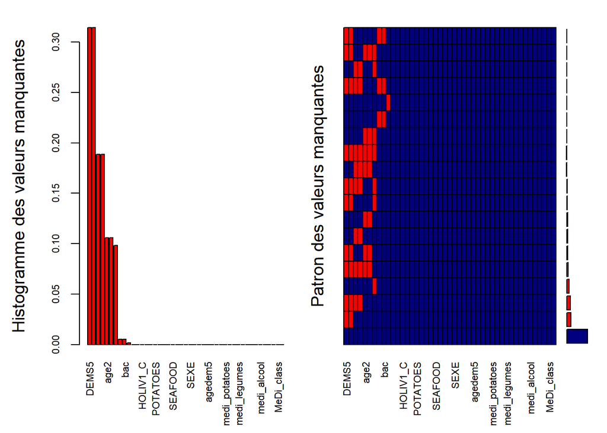

```
##
##  Variables sorted by number of missings:
##             Variable       Count
##                DEMS5 0.314474651
##                 age5 0.314474651
##                 AGE4 0.188831741
##                DEMS4 0.188831741
##                 age2 0.105804555
##                DEMS2 0.105804555
##                apoE4 0.098457017
##              etudeb0 0.005143277
##                  bac 0.005143277
##             DIABETE1 0.001469508
##              NUM_PAT 0.000000000
##               Alcool 0.000000000
##             HOLIV1_C 0.000000000
##             HOLIV1_A 0.000000000
##  NON_REFINED_CEREALS 0.000000000
##             POTATOES 0.000000000
##               FRUITS 0.000000000
##           VEGETABLES 0.000000000
##              LEGUMES 0.000000000
##              SEAFOOD 0.000000000
##                MEATS 0.000000000
##              POULTRY 0.000000000
##       DAIRY_PRODUCTS 0.000000000
##                 SEXE 0.000000000
##                 age1 0.000000000
##              agedem4 0.000000000
##              agedem2 0.000000000
##              agedem5 0.000000000
##                medic 0.000000000
##                 Acal 0.000000000
##         medi_cereals 0.000000000
##        medi_potatoes 0.000000000
##          medi_fruits 0.000000000
##      medi_vegetables 0.000000000
##         medi_legumes 0.000000000
##         medi_seafood 0.000000000
##            medi_meat 0.000000000
##         medi_poultry 0.000000000
##  medi_dairy_products 0.000000000
##          medi_alcool 0.000000000
##             holivtot 0.000000000
##           medi_holiv 0.000000000
##                 MeDi 0.000000000
##           MeDi_class 0.000000000
##             dementia 0.000000000
```

```r
# Visualiser les valeurs manquantes
aggr(data, col=c('navyblue','red'), numbers=TRUE, sortVars=TRUE, labels=names(data), cex.axis=.7, gap=3, ylab=c("Histogramme des valeurs manquantes","Patron des valeurs manquantes"))
```

Pour pouvoir décrire les individus ayant des valeurs manquantes et les comparer à ceux n’en ayant pas (donc comparer les inclus et les exclus), on divise le jeu de données data en deux jeux de données : dataNONA et dataNA. Comme on n’aura que très peu l’utilité des variables de nutrition (sauf pour quelques statistiques descriptives), on commence par les supprimer. On ne souhaite plus non plus avoir les suivis, qui peuvent introduire des erreurs à cause de valeurs manquantes pour les individus censurés à droite. On ne garde que les variables : NUM_PAT, SEXE, bac, Acal, DIABETE1, apoE4, medic, age1, agedem5, dementia, MeDi, MeDi_class :

```r
# Le jdd non manquantes ne prend pas les individus de suivi nul ni ceux ayant un NA, et on ne garde que 12 variables
dataNONA <- data %>%
  filter (agedem5 != age1) %>%
  select(NUM_PAT, SEXE, bac, Acal, DIABETE1, apoE4, medic, age1, agedem5, dementia, MeDi, MeDi_class) %>%
  na.omit(.)

# Le jdd manquantes prend tous les individus de suivi nul et ayant une donnée manquante, et ne garde que 12 variables
dataNA <- data %>%
  select(NUM_PAT, SEXE, bac, Acal, DIABETE1, apoE4, medic, age1, agedem5, dementia, MeDi, MeDi_class) %>%
  filter ((agedem5 == age1) | rowSums(is.na(.)) > 0)

# dataNA <- data %>%
#   filter (agedem5 == age1) %>%
#   select(NUM_PAT, SEXE, bac, Acal, DIABETE1, apoE4, medic, age1, agedem5, dementia, MeDi, MeDi_class)


nrow(dataNA) + nrow(dataNONA) == nrow (data)  #Les jdd se recoupent bien
```

```
## [1] TRUE
```

On décrit l’échantillon sans valeurs manquantes :

```r
# Desc est le jdd dataNONA mais avec toutes les variables de nutrition
dataID <- dataNONA %>% select (NUM_PAT)
desc <- merge(dataID,data,by="NUM_PAT",all.x=TRUE)
rm(dataID)
```

On décrit de nouvea à l’aide de tableau :

```r
# Données caractéristiques des sujets

desc %>%
  select(SEXE, bac,DIABETE1, apoE4, medic, age1) %>%
  tbl_summary(
    type = age1 ~ "continuous2",
    statistic = list(
      all_continuous2() ~ c("{mean} ({sd})", "{median} ({p25} - {p75})", "{min}-{max}"),
      c(SEXE, bac, DIABETE1, apoE4, medic) ~ "{p}% (n={n})"
    ),
    missing="no",
    label= list(SEXE~"Sexe",
                bac~"Niveau d'études",
                DIABETE1~"Diabète",
                apoE4~"APOE-4",
                medic~"Nb médicament/j",
                age1~"Age"),
    digits= list(all_continuous2()~c(2,2,0,1,1,0,0),
                 c(SEXE, bac, DIABETE1, apoE4, medic) ~c(2,0))
  ) %>%
  add_n()
```

| **Characteristic** | **N** | **N = 1,163**<sup>1</sup> |
| --- | --- | --- |
| Sexe | 1,163 |  |
| 0 |  | 63.80% (n=742) |
| 1 |  | 36.20% (n=421) |
| Niveau d'études | 1,163 | 39.64% (n=461) |
| Diabète | 1,163 |  |
| 0 |  | 90.37% (n=1,051) |
| 1 |  | 9.63% (n=112) |
| APOE-4 | 1,163 |  |
| 0 |  | 82.20% (n=956) |
| 1 |  | 17.80% (n=207) |
| Nb médicament/j | 1,163 |  |
| 0 |  | 50.56% (n=588) |
| 1 |  | 49.44% (n=575) |
| Age | 1,163 |  |
| Mean (SD) |  | 75.77 (4.78) |
| Median (IQR) |  | 75 (71.9 - 79.4) |
| Minimum-Maximum |  | 68-95 |

<sup>1</sup> % (n=n)

```r
# Données relatives à la nutrition

desc %>%
  select(NON_REFINED_CEREALS, POTATOES, FRUITS, VEGETABLES, LEGUMES, SEAFOOD, MEATS, POULTRY, DAIRY_PRODUCTS, HOLIV1_C, HOLIV1_A, Alcool, Acal) %>%
  tbl_summary(
    type = c(NON_REFINED_CEREALS, POTATOES, FRUITS, VEGETABLES, LEGUMES, SEAFOOD, MEATS, POULTRY, DAIRY_PRODUCTS, Alcool)  ~ "continuous2",
    statistic = list(
      all_continuous2() ~ c("{mean} ({sd})", "{median} ({p25} - {p75})", "{min}-{max}"),
      c(HOLIV1_C, HOLIV1_A, Acal) ~ "{p}% (n={n})"
    ),
    missing="no",
    label= list(NON_REFINED_CEREALS~"Céréales/Féculents complets (port./sem)",
                POTATOES~"Pommes de terre (port./sem)",
                FRUITS~"Fruits (port./sem)",
                VEGETABLES~"Légumes (port./sem)",
                LEGUMES~"Légumineuses (port./sem)",
                SEAFOOD~"Poissons (port./sem)",
                MEATS~"Viandes rouges (port./sem)",
                POULTRY~"Volailles (port./sem)",
                DAIRY_PRODUCTS~"Produits laitiers (port./sem)",
                HOLIV1_A~"Huile d'olive pour assaisonnement",
                HOLIV1_C~"Huile d'olive en cuisson",
                Alcool~"Alcool (ml/j)",
                Acal~"Apport énergétique"),
    digits= list(all_continuous2()~c(2,2,0,1,1,0,0),
                 c(HOLIV1_C, HOLIV1_A, Acal) ~c(2,0))
  ) %>%
  add_n()
```

| **Characteristic** | **N** | **N = 1,163**<sup>1</sup> |
| --- | --- | --- |
| Céréales/Féculents complets (port./sem) | 1,163 |  |
| Mean (SD) |  | 22.04 (6.15) |
| Median (IQR) |  | 23 (19.0 - 25.5) |
| Minimum-Maximum |  | 0-51 |
| Pommes de terre (port./sem) | 1,163 |  |
| Mean (SD) |  | 2.62 (1.70) |
| Median (IQR) |  | 2 (1.0 - 4.0) |
| Minimum-Maximum |  | 0-10 |
| Fruits (port./sem) | 1,163 |  |
| Mean (SD) |  | 13.43 (6.64) |
| Median (IQR) |  | 14 (9.0 - 17.0) |
| Minimum-Maximum |  | 0-42 |
| Légumes (port./sem) | 1,163 |  |
| Mean (SD) |  | 19.45 (7.22) |
| Median (IQR) |  | 19 (14.0 - 24.0) |
| Minimum-Maximum |  | 0-47 |
| Légumineuses (port./sem) | 1,163 |  |
| Mean (SD) |  | 0.62 (0.69) |
| Median (IQR) |  | 1 (0.3 - 1.0) |
| Minimum-Maximum |  | 0-8 |
| Poissons (port./sem) | 1,163 |  |
| Mean (SD) |  | 2.90 (1.75) |
| Median (IQR) |  | 3 (1.5 - 4.0) |
| Minimum-Maximum |  | 0-12 |
| Viandes rouges (port./sem) | 1,163 |  |
| Mean (SD) |  | 6.42 (3.56) |
| Median (IQR) |  | 6 (4.0 - 8.0) |
| Minimum-Maximum |  | 0-24 |
| Volailles (port./sem) | 1,163 |  |
| Mean (SD) |  | 1.82 (1.26) |
| Median (IQR) |  | 2 (1.0 - 2.0) |
| Minimum-Maximum |  | 0-8 |
| Produits laitiers (port./sem) | 1,163 |  |
| Mean (SD) |  | 18.09 (7.75) |
| Median (IQR) |  | 17 (14.0 - 22.5) |
| Minimum-Maximum |  | 0-63 |
| Huile d'olive en cuisson | 1,163 |  |
| 1 |  | 16.94% (n=197) |
| 2 |  | 8.86% (n=103) |
| 3 |  | 9.03% (n=105) |
| 4 |  | 65.18% (n=758) |
| Huile d'olive pour assaisonnement | 1,163 |  |
| 1 |  | 49.18% (n=572) |
| 2 |  | 7.74% (n=90) |
| 3 |  | 10.23% (n=119) |
| 4 |  | 32.85% (n=382) |
| Alcool (ml/j) | 1,163 |  |
| Mean (SD) |  | 12.78 (16.02) |
| Median (IQR) |  | 8 (0.0 - 19.2) |
| Minimum-Maximum |  | 0-109 |
| Apport énergétique | 1,163 |  |
| 0 |  | 32.67% (n=380) |
| 1 |  | 67.33% (n=783) |

<sup>1</sup> % (n=n)

On visualise les données décrites précédemment :

```r
# Afficher les nouvelles classes
table(desc$MeDi_class)
```

```
##
##   Bas Moyen  Haut
##   434   350   379
```

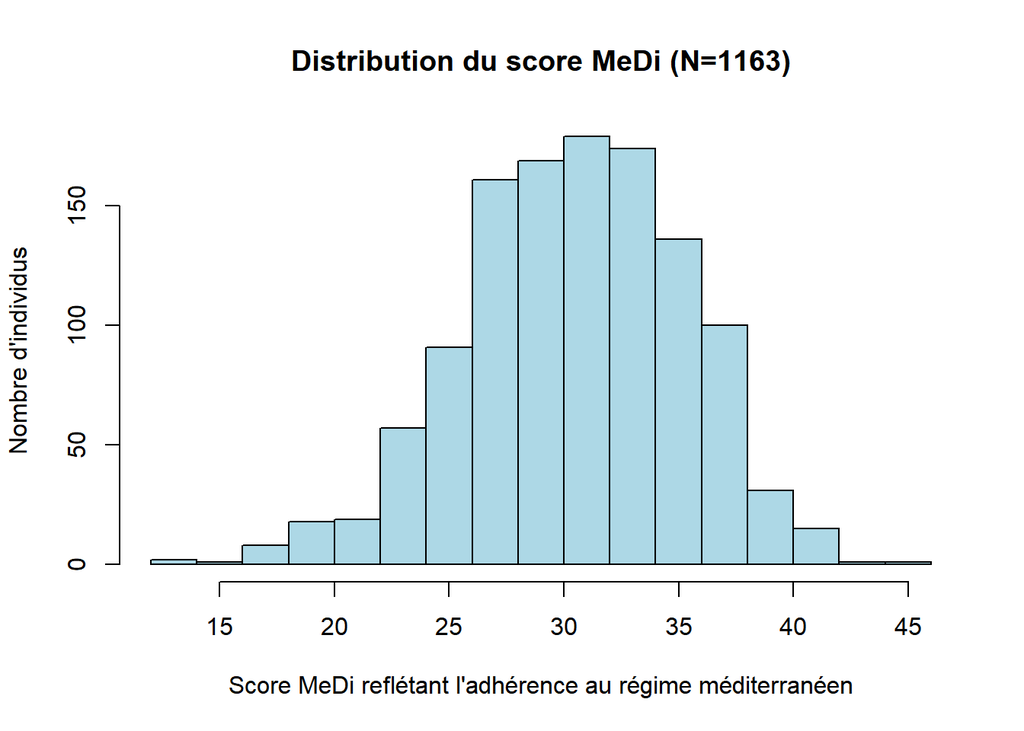

```r
# Créer un histogramme de la variable 'MeDi'
hist(desc$MeDi,
     main="Distribution du score MeDi (N=1163)",
     xlab="Score MeDi reflétant l'adhérence au régime méditerranéen",
     ylab="Nombre d'individus",
     col="lightblue",
     border="black",
     breaks=20) # 'breaks' ajuste le nombre de barres dans l'histogramme
```

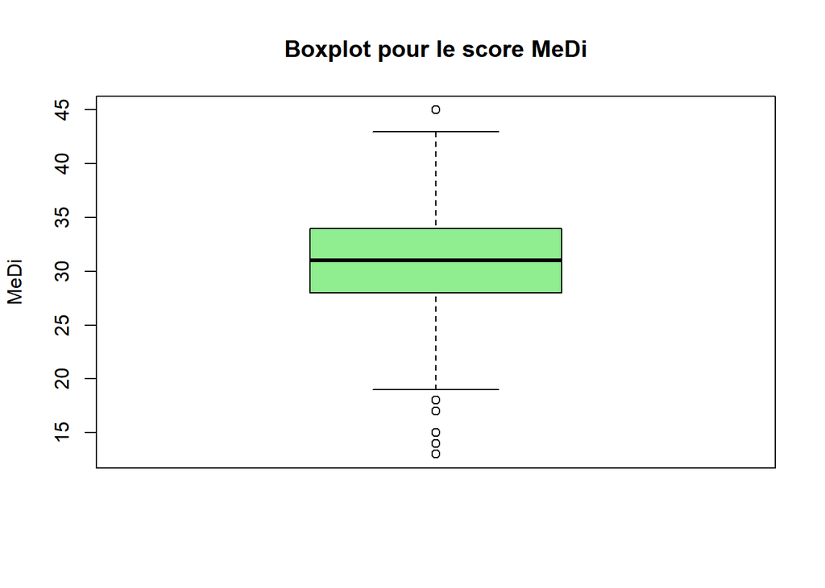

```r
# Créer un boxplot de la variable 'MeDi'
boxplot(desc$MeDi,
        main="Boxplot pour le score MeDi",
        ylab="MeDi",
        col="lightgreen")
```

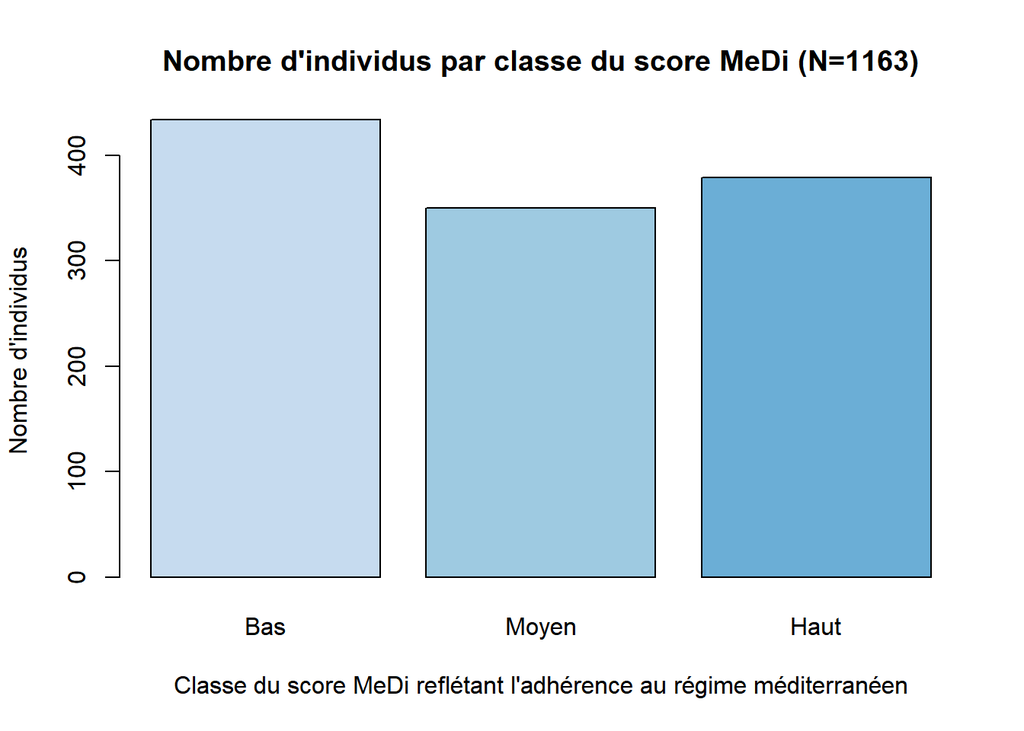

```r
# Créer un barchart avec les nombres affichés au-dessus des barres
effectifs <- table(desc$MeDi_class)
par(mar = c(5, 4, 4, 2) + 0.1)
bp <- barplot(effectifs,
              main = "Nombre d'individus par classe du score MeDi (N=1163)",
              xlab = "Classe du score MeDi reflétant l'adhérence au régime méditerranéen",
              ylab = "Nombre d'individus",
              col = c("#c6dbef", "#9ecae1", "#6baed6"),
              border = "black")
```

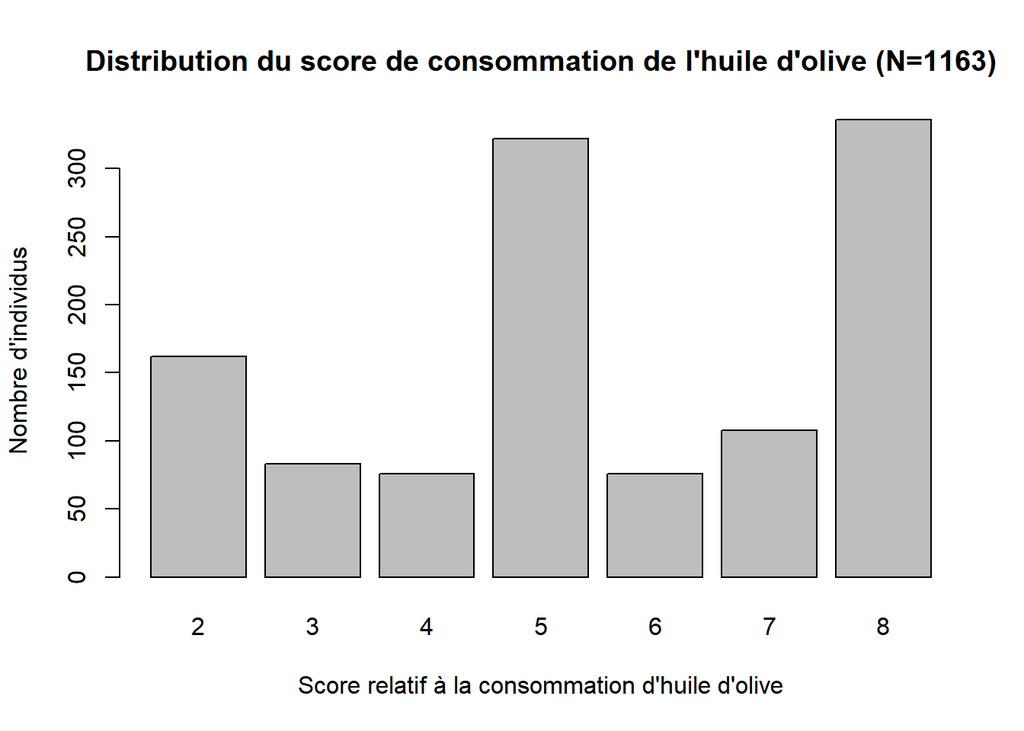

```r
# Ajouter les nombres au-dessus des barres
#text(bp, effectifs + 1, labels = effectifs, pos = 3)

barplot(table(desc$holivtot),main="Distribution du score de consommation de l'huile d'olive (N=1163)",xlab="Score relatif à la consommation d'huile d'olive",ylab="Nombre d'individus")
```

On réalise une description croisée du niveau de score MeDi et des variables de nutrition :

```r
desc %>%
  select(NON_REFINED_CEREALS, POTATOES, FRUITS, VEGETABLES, LEGUMES, SEAFOOD, MEATS, POULTRY, DAIRY_PRODUCTS, HOLIV1_C, HOLIV1_A, Alcool, Acal, MeDi_class) %>%
  tbl_summary(
    type = c(NON_REFINED_CEREALS, POTATOES, FRUITS, VEGETABLES, LEGUMES, SEAFOOD, MEATS, POULTRY, DAIRY_PRODUCTS, Alcool)  ~ "continuous2",
    statistic = list(
      all_continuous2() ~ c("{mean} ({sd})", "{median} ({p25} - {p75})", "{min}-{max}"),
      c(HOLIV1_C, HOLIV1_A, Acal) ~ "{p}% (n={n})"
    ),
    by=MeDi_class,
    missing="no",
    label= list(NON_REFINED_CEREALS~"Céréales/Féculents complets (port./sem)",
                POTATOES~"Pommes de terre (port./sem)",
                FRUITS~"Fruits (port./sem)",
                VEGETABLES~"Légumes (port./sem)",
                LEGUMES~"Légumineuses (port./sem)",
                SEAFOOD~"Poissons (port./sem)",
                MEATS~"Viandes rouges (port./sem)",
                POULTRY~"Volailles (port./sem)",
                DAIRY_PRODUCTS~"Produits laitiers (port./sem)",
                HOLIV1_A~"Huile d'olive pour assaisonnement",
                HOLIV1_C~"Huile d'olive en cuisson",
                Alcool~"Alcool (ml/j)",
                Acal~"Apport énergétique"),
    digits= list(all_continuous2()~c(2,2,0,1,1,0,0),
                 c(HOLIV1_C, HOLIV1_A, Acal) ~c(2,0))
  ) %>%
  add_n()
```

| **Characteristic** | **N** | **Bas**, N = 434<sup>1</sup> | **Moyen**, N = 350<sup>1</sup> | **Haut**, N = 379<sup>1</sup> |
| --- | --- | --- | --- | --- |
| Céréales/Féculents complets (port./sem) | 1,163 |  |  |  |
| Mean (SD) |  | 20.68 (6.73) | 21.88 (6.15) | 23.73 (4.95) |
| Median (IQR) |  | 22 (16.0 - 25.0) | 23 (19.0 - 25.0) | 24 (22.0 - 26.0) |
| Minimum-Maximum |  | 0-38 | 2-51 | 7-40 |
| Pommes de terre (port./sem) | 1,163 |  |  |  |
| Mean (SD) |  | 2.33 (1.62) | 2.67 (1.69) | 2.90 (1.75) |
| Median (IQR) |  | 2 (1.0 - 3.0) | 2 (1.0 - 4.0) | 3 (1.5 - 4.0) |
| Minimum-Maximum |  | 0-10 | 0-10 | 0-10 |
| Fruits (port./sem) | 1,163 |  |  |  |
| Mean (SD) |  | 11.28 (6.51) | 13.09 (6.21) | 16.20 (6.18) |
| Median (IQR) |  | 12 (7.0 - 14.2) | 14 (8.3 - 16.0) | 15 (13.0 - 21.0) |
| Minimum-Maximum |  | 0-39 | 0-33 | 2-42 |
| Légumes (port./sem) | 1,163 |  |  |  |
| Mean (SD) |  | 17.00 (6.95) | 19.87 (7.02) | 21.87 (6.81) |
| Median (IQR) |  | 17 (12.0 - 21.5) | 19 (15.0 - 24.0) | 21 (17.0 - 26.0) |
| Minimum-Maximum |  | 0-44 | 3-47 | 4-43 |
| Légumineuses (port./sem) | 1,163 |  |  |  |
| Mean (SD) |  | 0.50 (0.74) | 0.60 (0.56) | 0.78 (0.71) |
| Median (IQR) |  | 0 (0.0 - 0.5) | 1 (0.3 - 1.0) | 1 (0.3 - 1.0) |
| Minimum-Maximum |  | 0-8 | 0-4 | 0-6 |
| Poissons (port./sem) | 1,163 |  |  |  |
| Mean (SD) |  | 2.15 (1.40) | 2.84 (1.54) | 3.83 (1.88) |
| Median (IQR) |  | 2 (1.0 - 3.0) | 3 (2.0 - 3.8) | 4 (2.3 - 5.0) |
| Minimum-Maximum |  | 0-8 | 0-12 | 1-10 |
| Viandes rouges (port./sem) | 1,163 |  |  |  |
| Mean (SD) |  | 6.90 (3.60) | 6.78 (3.67) | 5.53 (3.23) |
| Median (IQR) |  | 7 (4.0 - 9.0) | 6 (4.0 - 9.0) | 5 (3.5 - 7.0) |
| Minimum-Maximum |  | 0-22 | 0-24 | 0-22 |
| Volailles (port./sem) | 1,163 |  |  |  |
| Mean (SD) |  | 1.82 (1.43) | 1.89 (1.21) | 1.76 (1.08) |
| Median (IQR) |  | 2 (1.0 - 2.0) | 2 (1.0 - 2.2) | 2 (1.0 - 2.0) |
| Minimum-Maximum |  | 0-8 | 0-6 | 0-5 |
| Produits laitiers (port./sem) | 1,163 |  |  |  |
| Mean (SD) |  | 19.96 (8.48) | 17.93 (7.33) | 16.10 (6.67) |
| Median (IQR) |  | 21 (14.0 - 25.9) | 17 (14.0 - 22.0) | 14 (12.0 - 21.0) |
| Minimum-Maximum |  | 0-63 | 1-52 | 0-35 |
| Huile d'olive en cuisson | 1,163 |  |  |  |
| 1 |  | 6.91% (n=30) | 15.71% (n=55) | 29.55% (n=112) |
| 2 |  | 4.61% (n=20) | 7.71% (n=27) | 14.78% (n=56) |
| 3 |  | 4.84% (n=21) | 9.43% (n=33) | 13.46% (n=51) |
| 4 |  | 83.64% (n=363) | 67.14% (n=235) | 42.22% (n=160) |
| Huile d'olive pour assaisonnement | 1,163 |  |  |  |
| 1 |  | 26.73% (n=116) | 52.00% (n=182) | 72.30% (n=274) |
| 2 |  | 6.22% (n=27) | 5.43% (n=19) | 11.61% (n=44) |
| 3 |  | 11.98% (n=52) | 12.57% (n=44) | 6.07% (n=23) |
| 4 |  | 55.07% (n=239) | 30.00% (n=105) | 10.03% (n=38) |
| Alcool (ml/j) | 1,163 |  |  |  |
| Mean (SD) |  | 6.51 (13.51) | 15.24 (17.51) | 17.69 (14.89) |
| Median (IQR) |  | 0 (0.0 - 7.6) | 10 (0.0 - 22.9) | 14 (7.2 - 23.0) |
| Minimum-Maximum |  | 0-90 | 0-109 | 0-91 |
| Apport énergétique | 1,163 |  |  |  |
| 0 |  | 26.04% (n=113) | 33.43% (n=117) | 39.58% (n=150) |
| 1 |  | 73.96% (n=321) | 66.57% (n=233) | 60.42% (n=229) |

<sup>1</sup> % (n=n)

## b) Description de l’huile d’olive

On décrit la variable de l’huile d’olive en fonction de la catégorie de score MeDi pour vérifier la cohérence du recodage précédemment effectué pour l’huile d’olive :

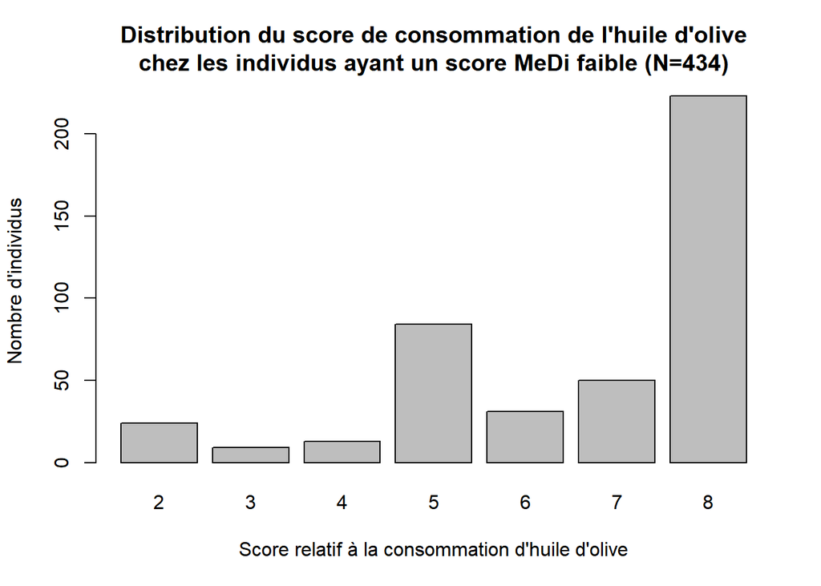

```r
# Description huile d'olive
data_faible <- desc %>% filter (MeDi_class == "Bas")
data_moyen <- desc %>% filter (MeDi_class == "Moyen")
data_haut <- desc %>% filter (MeDi_class == "Haut")

barplot(table(data_faible$holivtot),
        main = paste("Distribution du score de consommation de l'huile d'olive",
                     "chez les individus ayant un score MeDi faible (N=434)",
                     sep = "\n"),
        xlab = "Score relatif à la consommation d'huile d'olive",
        ylab = "Nombre d'individus")
```

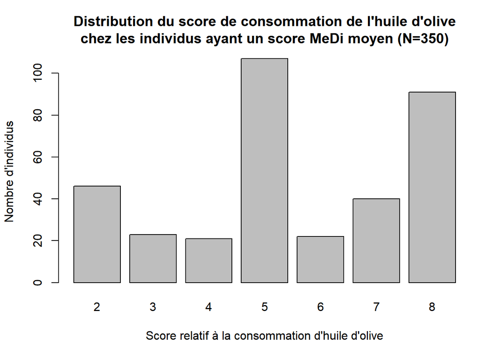

```r
barplot(table(data_moyen$holivtot),
        main = paste("Distribution du score de consommation de l'huile d'olive",
                     "chez les individus ayant un score MeDi moyen (N=350)",
                     sep = "\n"),
        xlab = "Score relatif à la consommation d'huile d'olive",
        ylab = "Nombre d'individus")
```

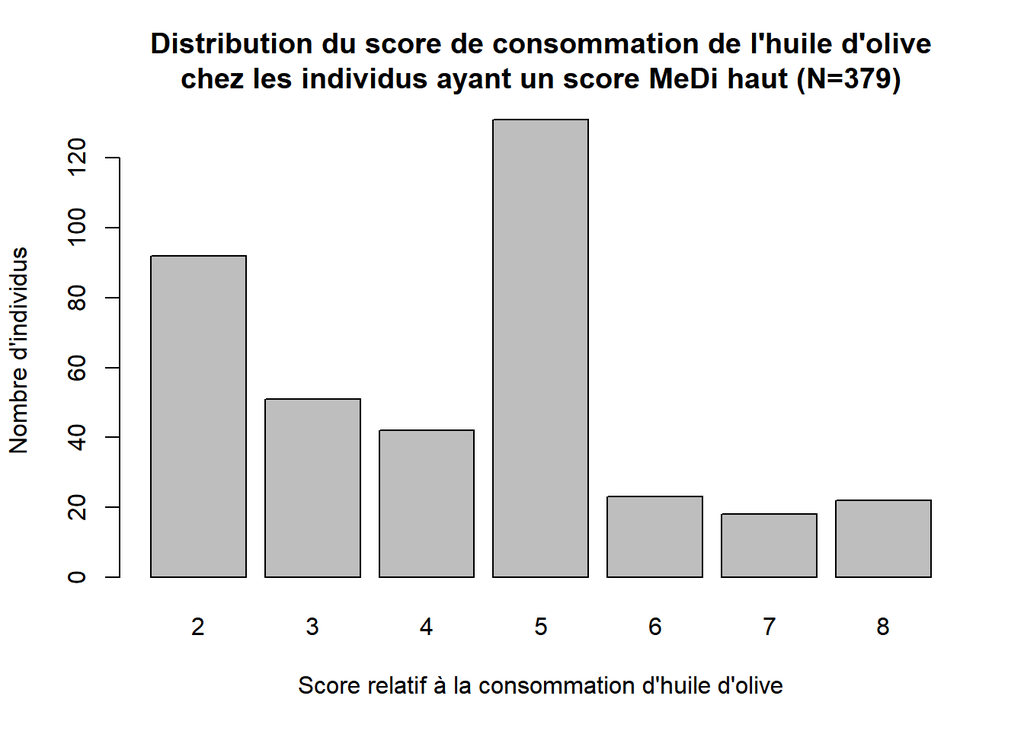

```r
barplot(table(data_haut$holivtot),
        main = paste("Distribution du score de consommation de l'huile d'olive",
                     "chez les individus ayant un score MeDi haut (N=379)",
                     sep = "\n"),
        xlab = "Score relatif à la consommation d'huile d'olive",
        ylab = "Nombre d'individus")
```

```r
rm(data_faible, data_moyen, data_haut)
```

## c) Description de la démence

On décrit ensuite la variable de la démence en fonction de la catégorie de score MeDi :

```r
# Description démence

desc %>%  select(MeDi_class, dementia) %>%
  tbl_summary (statistic= dementia ~ "{n} ({p}%)" ,
               by=MeDi_class, missing="no", digits= all_continuous() ~ c (0,2) ) %>%
  add_n()  %>%
  add_overall(last=TRUE)
```

| **Characteristic** | **N** | **Bas**, N = 434<sup>1</sup> | **Moyen**, N = 350<sup>1</sup> | **Haut**, N = 379<sup>1</sup> | **Overall**, N = 1,163<sup>1</sup> |
| --- | --- | --- | --- | --- | --- |
| dementia | 1,163 |  |  |  |  |
| 0 |  | 377 (87%) | 304 (87%) | 345 (91%) | 1,026 (88%) |
| 1 |  | 57 (13%) | 46 (13%) | 34 (9.0%) | 137 (12%) |

<sup>1</sup> n (%)

# 5. Analyse des données manquantes

On fusionne les jeux de données contenant uniquement des individus ayant des valeurs manquantes avec celui contenant uniquement des individus n’en ayant pas :

```r
dataNONA$dementia <- as.factor(dataNONA$dementia)
dataNA$dementia <- as.factor(dataNA$dementia)

# Ajouter une colonne GROUP dans chaque table
dataNA <- dataNA %>% mutate(GROUP = "EXCLUS")
dataNONA_13var <- dataNONA %>% mutate(GROUP = "INCLUS")

str(dataNA)
```

```
## 'data.frame':    198 obs. of  13 variables:
##  $ NUM_PAT   : int  10023 10024 10040 10067 10070 10072 10073 10092 10112 10113 ...
##  $ SEXE      : Factor w/ 2 levels "0","1": 1 1 1 2 2 1 1 1 2 1 ...
##  $ bac       : num  0 0 0 1 0 0 1 1 1 1 ...
##  $ Acal      : Factor w/ 2 levels "0","1": 2 2 2 1 1 1 1 2 1 2 ...
##  $ DIABETE1  : Factor w/ 2 levels "0","1": 1 1 1 1 1 1 1 1 1 1 ...
##  $ apoE4     : Factor w/ 2 levels "0","1": NA NA 1 NA 1 NA NA 1 1 1 ...
##  $ medic     : Factor w/ 2 levels "0","1": 1 2 2 1 2 1 1 2 1 1 ...
##  $ age1      : num  69 79.5 70.5 76.7 79.4 ...
##  $ agedem5   : num  76.3 82.9 70.5 84.2 79.4 ...
##  $ dementia  : Factor w/ 2 levels "0","1": 1 2 1 1 1 1 1 1 1 1 ...
##  $ MeDi      : num  36 32 33 34 26 32 29 30 35 35 ...
##  $ MeDi_class: Factor w/ 3 levels "Bas","Moyen",..: 3 2 2 3 1 2 1 2 3 3 ...
##  $ GROUP     : chr  "EXCLUS" "EXCLUS" "EXCLUS" "EXCLUS" ...
```

```r
str(dataNONA_13var)
```

```
## 'data.frame':    1163 obs. of  13 variables:
##  $ NUM_PAT   : int  10003 10005 10010 10011 10015 10016 10019 10022 10027 10028 ...
##  $ SEXE      : Factor w/ 2 levels "0","1": 1 1 1 1 1 1 1 1 1 1 ...
##  $ bac       : num  0 0 0 0 0 0 1 0 0 0 ...
##  $ Acal      : Factor w/ 2 levels "0","1": 2 2 1 1 2 1 2 1 2 2 ...
##  $ DIABETE1  : Factor w/ 2 levels "0","1": 1 1 1 1 1 1 1 1 1 1 ...
##  $ apoE4     : Factor w/ 2 levels "0","1": 1 1 1 1 2 2 2 1 1 1 ...
##  $ medic     : Factor w/ 2 levels "0","1": 2 2 2 2 1 2 2 2 2 2 ...
##  $ age1      : num  74.6 77.1 81.5 67.7 76.4 ...
##  $ agedem5   : num  82.3 81.1 88 75.6 84.5 ...
##  $ dementia  : Factor w/ 2 levels "0","1": 1 2 2 1 1 2 1 1 2 1 ...
##  $ MeDi      : num  25 31 40 37 37 30 28 30 32 32 ...
##  $ MeDi_class: Factor w/ 3 levels "Bas","Moyen",..: 1 2 3 3 3 2 1 2 2 2 ...
##  $ GROUP     : chr  "INCLUS" "INCLUS" "INCLUS" "INCLUS" ...
##  - attr(*, "na.action")= 'omit' Named int [1:133] 9 10 31 34 35 74 85 96 103 113 ...
##   ..- attr(*, "names")= chr [1:133] "9" "10" "31" "34" ...
```

```r
# Fusionner les tables selon la variable NUMPAT en incluant la nouvelle colonne GROUP
descNA <- bind_rows(dataNA, dataNONA_13var)

rm(dataNONA_13var)
```

On réalise les statistiques descriptives des deux jeux de données :

```r
# Description des différentes caractéristiques

descNA %>%
  dplyr::select(SEXE, bac,DIABETE1, apoE4, medic, age1, MeDi, MeDi_class, GROUP) %>%
  tbl_summary(
    type = c(age1, MeDi) ~ "continuous2",
    statistic = list(
      all_continuous2() ~ c("{mean} ({sd})", "{min}-{max}"),
      c(SEXE, bac, DIABETE1, apoE4, medic, MeDi_class) ~ "{p}% (n={n})"
    ),
    by=GROUP,
    label= list(SEXE~"Sexe",
                bac~"Niveau d'études",
                DIABETE1~"Diabète",
                apoE4~"APOE-4",
                medic~"Nb médicament/j",
                age1~"Age",
                MeDi~"Score MeDi",
                MeDi_class~"Classe de score MeDi"),
    digits= list(all_continuous2()~c(2,2,0,0),
                 c(SEXE, bac, DIABETE1, apoE4, medic, MeDi_class) ~c(2,0))
  ) %>%
  add_n()
```

| **Characteristic** | **N** | **EXCLUS**, N = 198<sup>1</sup> | **INCLUS**, N = 1,163<sup>1</sup> |
| --- | --- | --- | --- |
| Sexe | 1,361 |  |  |
| 0 |  | 60.61% (n=120) | 63.80% (n=742) |
| 1 |  | 39.39% (n=78) | 36.20% (n=421) |
| Niveau d'études | 1,354 | 39.27% (n=75) | 39.64% (n=461) |
| Unknown |  | 7 | 0 |
| Diabète | 1,359 |  |  |
| 0 |  | 88.27% (n=173) | 90.37% (n=1,051) |
| 1 |  | 11.73% (n=23) | 9.63% (n=112) |
| Unknown |  | 2 | 0 |
| APOE-4 | 1,227 |  |  |
| 0 |  | 79.69% (n=51) | 82.20% (n=956) |
| 1 |  | 20.31% (n=13) | 17.80% (n=207) |
| Unknown |  | 134 | 0 |
| Nb médicament/j | 1,361 |  |  |
| 0 |  | 41.41% (n=82) | 50.56% (n=588) |
| 1 |  | 58.59% (n=116) | 49.44% (n=575) |
| Age | 1,361 |  |  |
| Mean (SD) |  | 76.89 (5.35) | 75.77 (4.78) |
| Minimum-Maximum |  | 68-91 | 68-95 |
| Score MeDi | 1,361 |  |  |
| Mean (SD) |  | 29.81 (4.96) | 30.96 (4.80) |
| Minimum-Maximum |  | 15-42 | 13-45 |
| Classe de score MeDi | 1,361 |  |  |
| Bas |  | 43.43% (n=86) | 37.32% (n=434) |
| Moyen |  | 32.83% (n=65) | 30.09% (n=350) |
| Haut |  | 23.74% (n=47) | 32.59% (n=379) |

<sup>1</sup> % (n=n)

Enfin, on réalise des tests afin de déterminer si les différences observées dans les statistiques descriptives sont statistiquement significativement différentes ou non :

```r
# Tests

#Student pour age et score MeDi (0-55):
var.test(descNA$age1[descNA$GROUP=="EXCLUS"],descNA$age1[descNA$GROUP=="INCLUS"])
```

```
##
##  F test to compare two variances
##
## data:  descNA$age1[descNA$GROUP == "EXCLUS"] and descNA$age1[descNA$GROUP == "INCLUS"]
## F = 1.2539, num df = 197, denom df = 1162, p-value = 0.03098
## alternative hypothesis: true ratio of variances is not equal to 1
## 95 percent confidence interval:
##  1.020669 1.566091
## sample estimates:
## ratio of variances
##           1.253937
```

```r
t.test(descNA$age1[descNA$GROUP=="EXCLUS"],descNA$age1[descNA$GROUP=="INCLUS"],var.equal=F)
```

```
##
##  Welch Two Sample t-test
##
## data:  descNA$age1[descNA$GROUP == "EXCLUS"] and descNA$age1[descNA$GROUP == "INCLUS"]
## t = 2.7664, df = 253.33, p-value = 0.006085
## alternative hypothesis: true difference in means is not equal to 0
## 95 percent confidence interval:
##  0.322962 1.918956
## sample estimates:
## mean of x mean of y
##  76.88746  75.76651
```

```r
var.test(descNA$MeDi[descNA$GROUP=="EXCLUS"],descNA$MeDi[descNA$GROUP=="INCLUS"])
```

```
##
##  F test to compare two variances
##
## data:  descNA$MeDi[descNA$GROUP == "EXCLUS"] and descNA$MeDi[descNA$GROUP == "INCLUS"]
## F = 1.0669, num df = 197, denom df = 1162, p-value = 0.5325
## alternative hypothesis: true ratio of variances is not equal to 1
## 95 percent confidence interval:
##  0.8684161 1.3324779
## sample estimates:
## ratio of variances
##           1.066888
```

```r
t.test(descNA$MeDi[descNA$GROUP=="EXCLUS"],descNA$MeDi[descNA$GROUP=="INCLUS"],var.equal=T)
```

```
##
##  Two Sample t-test
##
## data:  descNA$MeDi[descNA$GROUP == "EXCLUS"] and descNA$MeDi[descNA$GROUP == "INCLUS"]
## t = -3.0972, df = 1359, p-value = 0.001993
## alternative hypothesis: true difference in means is not equal to 0
## 95 percent confidence interval:
##  -1.875404 -0.420947
## sample estimates:
## mean of x mean of y
##  29.81313  30.96131
```

```r
#Test Chi² pour les autres variables :
TAB<-table(descNA$GROUP,descNA$SEXE)
#TAB
# RC :
qchisq(p=0.95, df=prod(dim(TAB)-1))
```

```
## [1] 3.841459
```

```r
test <- chisq.test(x=TAB,correct=FALSE)
test
```

```
##
##  Pearson's Chi-squared test
##
## data:  TAB
## X-squared = 0.74351, df = 1, p-value = 0.3885
```

```r
test$expected # verif des effectifs théoriques
```

```
##
##                 0         1
##   EXCLUS 125.4048  72.59515
##   INCLUS 736.5952 426.40485
```

```r
TAB<-table(descNA$GROUP,descNA$bac)
#TAB
# RC :
qchisq(p=0.95, df=prod(dim(TAB)-1))
```

```
## [1] 3.841459
```

```r
test <- chisq.test(x=TAB,correct=FALSE)
test
```

```
##
##  Pearson's Chi-squared test
##
## data:  TAB
## X-squared = 0.0094852, df = 1, p-value = 0.9224
```

```r
test$expected # verif des effectifs théoriques
```

```
##
##               0         1
##   EXCLUS 115.39  75.61004
##   INCLUS 702.61 460.38996
```

```r
TAB<-table(descNA$GROUP,descNA$DIABETE1)
#TAB
# RC :
qchisq(p=0.95, df=prod(dim(TAB)-1))
```

```
## [1] 3.841459
```

```r
test <- chisq.test(x=TAB,correct=FALSE)
test
```

```
##
##  Pearson's Chi-squared test
##
## data:  TAB
## X-squared = 0.83025, df = 1, p-value = 0.3622
```

```r
test$expected # verif des effectifs théoriques
```

```
##
##                  0        1
##   EXCLUS  176.5298  19.4702
##   INCLUS 1047.4702 115.5298
```

```r
TAB<-table(descNA$GROUP,descNA$apoE4)
#TAB
# RC :
qchisq(p=0.95, df=prod(dim(TAB)-1))
```

```
## [1] 3.841459
```

```r
test <- chisq.test(x=TAB,correct=FALSE)
test
```

```
##
##  Pearson's Chi-squared test
##
## data:  TAB
## X-squared = 0.26048, df = 1, p-value = 0.6098
```

```r
test$expected # verif des effectifs théoriques
```

```
##
##                  0         1
##   EXCLUS  52.52486  11.47514
##   INCLUS 954.47514 208.52486
```

```r
TAB<-table(descNA$GROUP,descNA$medic)
#TAB
# RC :
qchisq(p=0.95, df=prod(dim(TAB)-1))
```

```
## [1] 3.841459
```

```r
test <- chisq.test(x=TAB,correct=FALSE)
test
```

```
##
##  Pearson's Chi-squared test
##
## data:  TAB
## X-squared = 5.661, df = 1, p-value = 0.01735
```

```r
test$expected # verif des effectifs théoriques
```

```
##
##                  0        1
##   EXCLUS  97.47245 100.5276
##   INCLUS 572.52755 590.4724
```

# 6. Taux d’incidence de la démence

## a) Taux d’incidence pour les classes de MeDi

Le nombre de personnes-années pour chaque classe de score MeDi correspond à la somme des temps de suivi selon chaque classe. La variable Agedem5 donne une information sur les dates de fin de suivi de tous les sujets : soit l’âge au moment de l’évènement, soit l’âge au dernier suivi.

Avec ces informations, on calcule les taux d’incidence pour chaque classe de score MeDi :

```r
incidence_rates_MeDi <- dataNONA %>%
  group_by(MeDi_class) %>%                       # Grouper par catégorie de MeDi_class
  summarize(
    cases = sum(dementia == 1, na.rm = TRUE),     # Nombre de cas de démence dans chaque catégorie
    person_year = sum(agedem5-age1, na.rm = TRUE)  # Somme des temps de suivi dans chaque catégorie
  ) %>%
  mutate(incidence_rate_MeDi = cases / person_year)
incidence_rates_MeDi
```

```
## # A tibble: 3 × 4
##   MeDi_class cases person_year incidence_rate_MeDi
##   <fct>      <int>       <dbl>               <dbl>
## 1 Bas           57       2724.              0.0209
## 2 Moyen         46       2149.              0.0214
## 3 Haut          34       2423.              0.0140
```

```r
rm(incidence_rates_MeDi)
```

## b) Taux d’incidence pour les classes d’âge

On créé donc les classes d’âge et on agrège les données selon celles-ci, en faisant en sorte que les individus puissent changer de classe d’âge grâce aux fonctions pyears et tcut, avant de calculer les taux d’incidence par classe d’âge :

```r
dataNONA$dementia <- as.numeric(dataNONA$dementia)

dataNONA$delaiglobal <- dataNONA$agedem5 - dataNONA$age1
tabverif <- dataNONA %>% select (agedem5, age1, delaiglobal)
#View(tabverif)


#On cree d'abord les classes d'age
dataNONA$temp.age <- tcut (dataNONA$age1, c(65,75,85,105))
tabverif <- dataNONA %>% dplyr::select (temp.age, age1)
#View(tabverif)
head(dataNONA$temp.age)
```

```
## [1] 74.57632 77.13895 81.51677 67.69336 76.41342 75.78645
## attr(,"cutpoints")
## [1]  65  75  85 105
## attr(,"labels")
## [1] "65+ thru  75" "75+ thru  85" "85+ thru 105"
## attr(,"class")
## [1] "tcut"
```

```r
#On lui demande de balayer toutes les classes d'âge pour calculer le nombre de personnes annees pour chaque
#classes d'âge, et on rajoute le sexe.
pfit <- pyears(Surv(delaiglobal,dementia) ~ temp.age , dataNONA, data.frame=TRUE)
tdata <- pfit$data
tdata$pa <- tdata$pyears*365.25
tdata
```

```
##       temp.age    pyears    n event        pa
## 1 65+ thru  75  4.817971  562     6 1759.7639
## 2 75+ thru  85 12.745048 1070    81 4655.1287
## 3 85+ thru 105  2.413296  310    50  881.4565
```

```r
tdata$incidence_rate_ageclass <- tdata$event/tdata$pa
tdata
```

```
##       temp.age    pyears    n event        pa incidence_rate_ageclass
## 1 65+ thru  75  4.817971  562     6 1759.7639             0.003409548
## 2 75+ thru  85 12.745048 1070    81 4655.1287             0.017400163
## 3 85+ thru 105  2.413296  310    50  881.4565             0.056724294
```

```r
rm(tabverif)
```

## c) Taux d’incidence global dans l’échantillon

On estime à présent le modèle sans variables explicatives, avec uniquement l’évènement de la démence et les personnes années (sous la forme du log) :

```r
# Taux d'incidence global dans l'échantillon

fitglobal <- glm (event ~ 1
                  + offset(log(pa)),
                  data=tdata, family=poisson)
summary(fitglobal)
```

```
##
## Call:
## glm(formula = event ~ 1 + offset(log(pa)), family = poisson,
##     data = tdata)
##
## Coefficients:
##             Estimate Std. Error z value Pr(>|z|)
## (Intercept) -3.97515    0.08544  -46.53   <2e-16 ***
## ---
## Signif. codes:  0 '***' 0.001 '**' 0.01 '*' 0.05 '.' 0.1 ' ' 1
##
## (Dispersion parameter for poisson family taken to be 1)
##
##     Null deviance: 77.755  on 2  degrees of freedom
## Residual deviance: 77.755  on 2  degrees of freedom
## AIC: 95.4
##
## Number of Fisher Scoring iterations: 5
```

En mettant à l’exponentielle le coefficient estimé de ce modèle sans variables, on obtient le taux d’incidence global dans l’échantillon.

# 7. Choix des covariables du modèle

Le choix est fait d’utiliser une procédure descendante puisque la littérature suggère que toutes les variables sont potentiellement importantes. Le choix est donc fait de toutes les inclure au départ, avant de tenter d’en enlever.

Une table de données agrégées en personnes-années selon toutes les covariables est créée. Les régressions de Poisson seront réalisées à partir de ce jeu de données :

```r
##Convert dementia
dataNONA$dementia <- ifelse(dataNONA$dementia == 2, 1, 0)

#Convert type
dataNONA$bac <- as.factor(dataNONA$bac)
#dataNONA$dementia <- as.numeric(dataNONA$dementia)



#table(dataNONA$dementia)

pfit <- pyears(Surv(time = delaiglobal, event = dementia, type = "right") ~ temp.age
               + MeDi_class
               + SEXE
               + bac
               + DIABETE1
               + apoE4
               + medic
               + Acal
               , data = dataNONA, data.frame = TRUE)

# Extraire les données groupées
tdata <- pfit$data

# Calcul des personnes-années à partir des personnes-jours
tdata$pa <- tdata$pyears * 365.25
```

Le modèle contenant l’ensemble des variables est donc le suivant :

```r
class(tdata$temp.age)
```

```
## [1] "factor"
```

```r
fit <- glm (event ~ temp.age
               + MeDi_class
               + SEXE
               + bac
               + DIABETE1
               + apoE4
               + medic
               + Acal
               + offset(log(pa)),
             data=tdata, family=poisson)
summary(tdata$pa)
```

```
##     Min.  1st Qu.   Median     Mean  3rd Qu.     Max.
##   0.1034   4.2719  10.0643  21.8454  25.8167 329.1663
```

```r
summary(fit)
```

```
##
## Call:
## glm(formula = event ~ temp.age + MeDi_class + SEXE + bac + DIABETE1 +
##     apoE4 + medic + Acal + offset(log(pa)), family = poisson,
##     data = tdata)
##
## Coefficients:
##                      Estimate Std. Error z value Pr(>|z|)
## (Intercept)          -6.28270    0.47931 -13.108  < 2e-16 ***
## temp.age75+ thru  85  1.63271    0.42366   3.854 0.000116 ***
## temp.age85+ thru 105  2.88485    0.43485   6.634 3.26e-11 ***
## MeDi_classMoyen       0.02432    0.19918   0.122 0.902812
## MeDi_classHaut       -0.32738    0.22389  -1.462 0.143684
## SEXE1                 0.10860    0.20051   0.542 0.588099
## bac1                 -0.14566    0.18648  -0.781 0.434728
## DIABETE11             0.84321    0.22976   3.670 0.000243 ***
## apoE41                0.53139    0.20277   2.621 0.008775 **
## medic1                0.45586    0.18534   2.460 0.013907 *
## Acal1                 0.29642    0.20534   1.444 0.148853
## ---
## Signif. codes:  0 '***' 0.001 '**' 0.01 '*' 0.05 '.' 0.1 ' ' 1
##
## (Dispersion parameter for poisson family taken to be 1)
##
##     Null deviance: 351.54  on 333  degrees of freedom
## Residual deviance: 234.09  on 323  degrees of freedom
## AIC: 451.44
##
## Number of Fisher Scoring iterations: 6
```

On réalise les modèles univariés afin d’identifier les variables qui ne semblent pas apporter beaucoup d’information de celles qui en apportent déjà :

```r
# Univariés


#Modèle sans covariables

fit0 <- glm (event ~ 1
             + offset(log(pa)),
             data=tdata, family=poisson)
summary(fit0)
```

```
##
## Call:
## glm(formula = event ~ 1 + offset(log(pa)), family = poisson,
##     data = tdata)
##
## Coefficients:
##             Estimate Std. Error z value Pr(>|z|)
## (Intercept) -3.97515    0.08544  -46.53   <2e-16 ***
## ---
## Signif. codes:  0 '***' 0.001 '**' 0.01 '*' 0.05 '.' 0.1 ' ' 1
##
## (Dispersion parameter for poisson family taken to be 1)
##
##     Null deviance: 351.54  on 333  degrees of freedom
## Residual deviance: 351.54  on 333  degrees of freedom
## AIC: 548.89
##
## Number of Fisher Scoring iterations: 6
```

```r
fit1 <- glm (event ~ temp.age
             + offset(log(pa)),
             data=tdata, family=poisson)
summary(fit1)
```

```
##
## Call:
## glm(formula = event ~ temp.age + offset(log(pa)), family = poisson,
##     data = tdata)
##
## Coefficients:
##                      Estimate Std. Error z value Pr(>|z|)
## (Intercept)           -5.6812     0.4082 -13.916  < 2e-16 ***
## temp.age75+ thru  85   1.6299     0.4231   3.852 0.000117 ***
## temp.age85+ thru 105   2.8116     0.4320   6.508 7.63e-11 ***
## ---
## Signif. codes:  0 '***' 0.001 '**' 0.01 '*' 0.05 '.' 0.1 ' ' 1
##
## (Dispersion parameter for poisson family taken to be 1)
##
##     Null deviance: 351.54  on 333  degrees of freedom
## Residual deviance: 273.79  on 331  degrees of freedom
## AIC: 475.14
##
## Number of Fisher Scoring iterations: 7
```

```r
exp(coef(fit1))
```

```
##          (Intercept) temp.age75+ thru  85 temp.age85+ thru 105
##          0.003409548          5.103363141         16.636893854
```

```r
exp(confint(fit1))
```

```
## Attente de la réalisation du profilage...
```

```
##                            2.5 %       97.5 %
## (Intercept)          0.001355052  0.006908391
## temp.age75+ thru  85 2.425935612 13.124273613
## temp.age85+ thru 105 7.729731910 43.346332887
```

```r
fit2 <- glm (event ~ MeDi_class
            + offset(log(pa)),
            data=tdata, family=poisson)
summary(fit2)
```

```
##
## Call:
## glm(formula = event ~ MeDi_class + offset(log(pa)), family = poisson,
##     data = tdata)
##
## Coefficients:
##                 Estimate Std. Error z value Pr(>|z|)
## (Intercept)     -3.86696    0.13245 -29.195   <2e-16 ***
## MeDi_classMoyen  0.02278    0.19820   0.115   0.9085
## MeDi_classHaut  -0.39937    0.21669  -1.843   0.0653 .
## ---
## Signif. codes:  0 '***' 0.001 '**' 0.01 '*' 0.05 '.' 0.1 ' ' 1
##
## (Dispersion parameter for poisson family taken to be 1)
##
##     Null deviance: 351.54  on 333  degrees of freedom
## Residual deviance: 346.96  on 331  degrees of freedom
## AIC: 548.31
##
## Number of Fisher Scoring iterations: 6
```

```r
exp(coef(fit2))
```

```
##     (Intercept) MeDi_classMoyen  MeDi_classHaut
##      0.02092198      1.02303725      0.67074509
```

```r
exp(confint(fit2))
```

```
## Attente de la réalisation du profilage...
```

```
##                      2.5 %     97.5 %
## (Intercept)     0.01594999 0.02683312
## MeDi_classMoyen 0.69099636 1.50647429
## MeDi_classHaut  0.43458828 1.01952642
```

```r
fit3 <- glm (event ~ SEXE
            + offset(log(pa)),
            data=tdata, family=poisson)
summary(fit3)
```

```
##
## Call:
## glm(formula = event ~ SEXE + offset(log(pa)), family = poisson,
##     data = tdata)
##
## Coefficients:
##             Estimate Std. Error z value Pr(>|z|)
## (Intercept)  -3.9312     0.1031 -38.114   <2e-16 ***
## SEXE1        -0.1339     0.1841  -0.727    0.467
## ---
## Signif. codes:  0 '***' 0.001 '**' 0.01 '*' 0.05 '.' 0.1 ' ' 1
##
## (Dispersion parameter for poisson family taken to be 1)
##
##     Null deviance: 351.54  on 333  degrees of freedom
## Residual deviance: 351.00  on 332  degrees of freedom
## AIC: 550.36
##
## Number of Fisher Scoring iterations: 6
```

```r
exp(coef(fit3))
```

```
## (Intercept)       SEXE1
##  0.01962079  0.87469238
```

```r
exp(confint(fit3))
```

```
## Attente de la réalisation du profilage...
```

```
##                  2.5 %     97.5 %
## (Intercept) 0.01591691 0.02385874
## SEXE1       0.60419288 1.24590995
```

```r
fit4 <- glm (event ~ bac
            + offset(log(pa)),
            data=tdata, family=poisson)
summary(fit4)
```

```
##
## Call:
## glm(formula = event ~ bac + offset(log(pa)), family = poisson,
##     data = tdata)
##
## Coefficients:
##             Estimate Std. Error z value Pr(>|z|)
## (Intercept)  -3.8613     0.1043 -37.036   <2e-16 ***
## bac1         -0.3126     0.1819  -1.719   0.0857 .
## ---
## Signif. codes:  0 '***' 0.001 '**' 0.01 '*' 0.05 '.' 0.1 ' ' 1
##
## (Dispersion parameter for poisson family taken to be 1)
##
##     Null deviance: 351.54  on 333  degrees of freedom
## Residual deviance: 348.49  on 332  degrees of freedom
## AIC: 547.84
##
## Number of Fisher Scoring iterations: 6
```

```r
exp(coef(fit4))
```

```
## (Intercept)        bac1
##  0.02104023  0.73150697
```

```r
exp(confint(fit4))
```

```
## Attente de la réalisation du profilage...
```

```
##                  2.5 %     97.5 %
## (Intercept) 0.01702848 0.02563713
## bac1        0.50789789 1.03829020
```

```r
fit5 <- glm (event ~ DIABETE1
            + offset(log(pa)),
            data=tdata, family=poisson)
summary(fit5)
```

```
##
## Call:
## glm(formula = event ~ DIABETE1 + offset(log(pa)), family = poisson,
##     data = tdata)
##
## Coefficients:
##             Estimate Std. Error z value Pr(>|z|)
## (Intercept) -4.09944    0.09492 -43.190  < 2e-16 ***
## DIABETE11    0.95672    0.21788   4.391 1.13e-05 ***
## ---
## Signif. codes:  0 '***' 0.001 '**' 0.01 '*' 0.05 '.' 0.1 ' ' 1
##
## (Dispersion parameter for poisson family taken to be 1)
##
##     Null deviance: 351.54  on 333  degrees of freedom
## Residual deviance: 335.85  on 332  degrees of freedom
## AIC: 535.2
##
## Number of Fisher Scoring iterations: 6
```

```r
exp(coef(fit5))
```

```
## (Intercept)   DIABETE11
##  0.01658199  2.60313346
```

```r
exp(confint(fit5))
```

```
## Attente de la réalisation du profilage...
```

```
##                  2.5 %     97.5 %
## (Intercept) 0.01368538 0.01986082
## DIABETE11   1.66348094 3.92212787
```

```r
fit6 <- glm (event ~ apoE4
            + offset(log(pa)),
            data=tdata, family=poisson)
summary(fit6)
```

```
##
## Call:
## glm(formula = event ~ apoE4 + offset(log(pa)), family = poisson,
##     data = tdata)
##
## Coefficients:
##             Estimate Std. Error z value Pr(>|z|)
## (Intercept) -4.06521    0.09806 -41.457   <2e-16 ***
## apoE41       0.44248    0.19980   2.215   0.0268 *
## ---
## Signif. codes:  0 '***' 0.001 '**' 0.01 '*' 0.05 '.' 0.1 ' ' 1
##
## (Dispersion parameter for poisson family taken to be 1)
##
##     Null deviance: 351.54  on 333  degrees of freedom
## Residual deviance: 347.01  on 332  degrees of freedom
## AIC: 546.37
##
## Number of Fisher Scoring iterations: 6
```

```r
exp(coef(fit6))
```

```
## (Intercept)      apoE41
##  0.01715936  1.55655619
```

```r
exp(confint(fit6))
```

```
## Attente de la réalisation du profilage...
```

```
##                  2.5 %     97.5 %
## (Intercept) 0.01406921 0.02067166
## apoE41      1.03687626 2.27533677
```

```r
fit7 <- glm (event ~ medic
            + offset(log(pa)),
            data=tdata, family=poisson)
summary(fit7)
```

```
##
## Call:
## glm(formula = event ~ medic + offset(log(pa)), family = poisson,
##     data = tdata)
##
## Coefficients:
##             Estimate Std. Error z value Pr(>|z|)
## (Intercept)  -4.3829     0.1443 -30.366  < 2e-16 ***
## medic1        0.7246     0.1791   4.046  5.2e-05 ***
## ---
## Signif. codes:  0 '***' 0.001 '**' 0.01 '*' 0.05 '.' 0.1 ' ' 1
##
## (Dispersion parameter for poisson family taken to be 1)
##
##     Null deviance: 351.54  on 333  degrees of freedom
## Residual deviance: 334.29  on 332  degrees of freedom
## AIC: 533.65
##
## Number of Fisher Scoring iterations: 6
```

```r
exp(coef(fit7))
```

```
## (Intercept)      medic1
##  0.01248848  2.06399170
```

```r
exp(confint(fit7))
```

```
## Attente de la réalisation du profilage...
```

```
##                   2.5 %     97.5 %
## (Intercept) 0.009280525 0.01636213
## medic1      1.460668100 2.95274196
```

```r
fit8 <- glm (event ~ Acal
            + offset(log(pa)),
            data=tdata, family=poisson)
summary(fit8)
```

```
##
## Call:
## glm(formula = event ~ Acal + offset(log(pa)), family = poisson,
##     data = tdata)
##
## Coefficients:
##             Estimate Std. Error z value Pr(>|z|)
## (Intercept)  -4.2236     0.1690 -24.988   <2e-16 ***
## Acal1         0.3503     0.1959   1.788   0.0738 .
## ---
## Signif. codes:  0 '***' 0.001 '**' 0.01 '*' 0.05 '.' 0.1 ' ' 1
##
## (Dispersion parameter for poisson family taken to be 1)
##
##     Null deviance: 351.54  on 333  degrees of freedom
## Residual deviance: 348.17  on 332  degrees of freedom
## AIC: 547.52
##
## Number of Fisher Scoring iterations: 6
```

```r
exp(coef(fit8))
```

```
## (Intercept)       Acal1
##  0.01464561  1.41943691
```

```r
exp(confint(fit8))
```

```
## Attente de la réalisation du profilage...
```

```
##                  2.5 %     97.5 %
## (Intercept) 0.01031384 0.02004741
## Acal1       0.97736557 2.11183232
```

Des tests du rapport de vraisemblance sont réalisés (de deux manières différentes) afin de savoir si les modèles univariables créés sont significativement plus intéressants que le modèle ne contenant aucune variable explicative :

```r
# Liste contenant les modèles
models <- list(fit1, fit2, fit3, fit4, fit5, fit6, fit7, fit8)

# Boucle pour tests du rapport de vraisemblance pour comparer chaque modèle au modèle sans variable
for (i in 1:2) {
  cat("Test rapport VR entre modèle vide et fit", i, ":\n", sep = "")
  print(anova(fit0, models[[i]], test = "LRT"))
  cat("\n")  # Pour une séparation entre les résultats
}
```

```
## Test rapport VR entre modèle vide et fit1:
## Analysis of Deviance Table
##
## Model 1: event ~ 1 + offset(log(pa))
## Model 2: event ~ temp.age + offset(log(pa))
##   Resid. Df Resid. Dev Df Deviance  Pr(>Chi)
## 1       333     351.54
## 2       331     273.79  2   77.755 < 2.2e-16 ***
## ---
## Signif. codes:  0 '***' 0.001 '**' 0.01 '*' 0.05 '.' 0.1 ' ' 1
##
## Test rapport VR entre modèle vide et fit2:
## Analysis of Deviance Table
##
## Model 1: event ~ 1 + offset(log(pa))
## Model 2: event ~ MeDi_class + offset(log(pa))
##   Resid. Df Resid. Dev Df Deviance Pr(>Chi)
## 1       333     351.54
## 2       331     346.96  2   4.5835   0.1011
```

```r
# Boucle pour tester chaque variable séparément : même résultat en univariable
for (i in 3:8) {
  cat("Wald fit", i, ":\n", sep = "")
  print(drop1(models[[i]],test="Chisq"))
  cat("\n")  # Pour une séparation entre les résultats
}
```

```
## Wald fit3:
## Single term deletions
##
## Model:
## event ~ SEXE + offset(log(pa))
##        Df Deviance    AIC     LRT Pr(>Chi)
## <none>      351.00 550.36
## SEXE    1   351.54 548.89 0.53739   0.4635
##
## Wald fit4:
## Single term deletions
##
## Model:
## event ~ bac + offset(log(pa))
##        Df Deviance    AIC    LRT Pr(>Chi)
## <none>      348.49 547.84
## bac     1   351.54 548.89 3.0509  0.08069 .
## ---
## Signif. codes:  0 '***' 0.001 '**' 0.01 '*' 0.05 '.' 0.1 ' ' 1
##
## Wald fit5:
## Single term deletions
##
## Model:
## event ~ DIABETE1 + offset(log(pa))
##          Df Deviance    AIC    LRT  Pr(>Chi)
## <none>        335.85 535.20
## DIABETE1  1   351.54 548.89 15.694 7.447e-05 ***
## ---
## Signif. codes:  0 '***' 0.001 '**' 0.01 '*' 0.05 '.' 0.1 ' ' 1
##
## Wald fit6:
## Single term deletions
##
## Model:
## event ~ apoE4 + offset(log(pa))
##        Df Deviance    AIC    LRT Pr(>Chi)
## <none>      347.01 546.37
## apoE4   1   351.54 548.89 4.5261  0.03338 *
## ---
```

[output cut: 8 more lines]

```
## <none>      334.29 533.65
## medic   1   351.54 548.89 17.249 3.279e-05 ***
## ---
## Signif. codes:  0 '***' 0.001 '**' 0.01 '*' 0.05 '.' 0.1 ' ' 1
##
## Wald fit8:
## Single term deletions
##
## Model:
## event ~ Acal + offset(log(pa))
##        Df Deviance    AIC    LRT Pr(>Chi)
## <none>      348.17 547.52
## Acal    1   351.54 548.89 3.3733  0.06626 .
## ---
## Signif. codes:  0 '***' 0.001 '**' 0.01 '*' 0.05 '.' 0.1 ' ' 1
```

```r
# Supprimer les modèles de l'environnement de travail
rm(fit1, fit2, fit3, fit4, fit5, fit6, fit7, fit8, test_na_nutrition)
```

Le modèle complet à partir duquel réaliser la procédure descendante est donc le suivant :

```r
class(tdata$temp.age)
```

```
## [1] "factor"
```

```r
fit1 <- glm (event ~ temp.age
               + MeDi_class
               + SEXE
               + bac
               + DIABETE1
               + apoE4
               + medic
               + Acal
               + offset(log(pa)),
             data=tdata, family=poisson)
summary(tdata$pa)
```

```
##     Min.  1st Qu.   Median     Mean  3rd Qu.     Max.
##   0.1034   4.2719  10.0643  21.8454  25.8167 329.1663
```

```r
summary(fit1)
```

```
##
## Call:
## glm(formula = event ~ temp.age + MeDi_class + SEXE + bac + DIABETE1 +
##     apoE4 + medic + Acal + offset(log(pa)), family = poisson,
##     data = tdata)
##
## Coefficients:
##                      Estimate Std. Error z value Pr(>|z|)
## (Intercept)          -6.28270    0.47931 -13.108  < 2e-16 ***
## temp.age75+ thru  85  1.63271    0.42366   3.854 0.000116 ***
## temp.age85+ thru 105  2.88485    0.43485   6.634 3.26e-11 ***
## MeDi_classMoyen       0.02432    0.19918   0.122 0.902812
## MeDi_classHaut       -0.32738    0.22389  -1.462 0.143684
## SEXE1                 0.10860    0.20051   0.542 0.588099
## bac1                 -0.14566    0.18648  -0.781 0.434728
## DIABETE11             0.84321    0.22976   3.670 0.000243 ***
## apoE41                0.53139    0.20277   2.621 0.008775 **
## medic1                0.45586    0.18534   2.460 0.013907 *
## Acal1                 0.29642    0.20534   1.444 0.148853
## ---
## Signif. codes:  0 '***' 0.001 '**' 0.01 '*' 0.05 '.' 0.1 ' ' 1
##
## (Dispersion parameter for poisson family taken to be 1)
##
##     Null deviance: 351.54  on 333  degrees of freedom
## Residual deviance: 234.09  on 323  degrees of freedom
## AIC: 451.44
##
## Number of Fisher Scoring iterations: 6
```

# 8. Choix des interactions

D’après la littérature on ne pense retenir qu’âge et sexe pour les interactions, cependant on se pose également la question pour diabète. On inclut donc ces trois interactions dans le modèle :

```r
fit2 <- glm (event ~ temp.age
               + MeDi_class
               + SEXE
               + bac
               + DIABETE1
               + apoE4
               + medic
               + Acal
               + offset(log(pa))
             + SEXE:MeDi_class
             + temp.age:MeDi_class
             + DIABETE1:MeDi_class,
             data=tdata, family=poisson)
summary(tdata$pa)
```

```
##     Min.  1st Qu.   Median     Mean  3rd Qu.     Max.
##   0.1034   4.2719  10.0643  21.8454  25.8167 329.1663
```

```r
summary(fit2)
```

```
##
## Call:
## glm(formula = event ~ temp.age + MeDi_class + SEXE + bac + DIABETE1 +
##     apoE4 + medic + Acal + offset(log(pa)) + SEXE:MeDi_class +
##     temp.age:MeDi_class + DIABETE1:MeDi_class, family = poisson,
##     data = tdata)
##
## Coefficients:
##                                      Estimate Std. Error z value Pr(>|z|)
## (Intercept)                           -5.7048     0.5582 -10.220  < 2e-16 ***
## temp.age75+ thru  85                   1.1413     0.5306   2.151  0.03146 *
## temp.age85+ thru 105                   2.4079     0.5512   4.369 1.25e-05 ***
## MeDi_classMoyen                       -1.2434     1.1352  -1.095  0.27337
## MeDi_classHaut                        -1.2957     1.1425  -1.134  0.25676
## SEXE1                                  0.1504     0.3274   0.459  0.64600
## bac1                                  -0.1757     0.1877  -0.936  0.34941
## DIABETE11                              0.4169     0.3748   1.112  0.26603
## apoE41                                 0.5531     0.2036   2.717  0.00659 **
## medic1                                 0.4292     0.1858   2.311  0.02086 *
## Acal1                                  0.2608     0.2071   1.259  0.20803
## MeDi_classMoyen:SEXE1                 -0.4155     0.4682  -0.888  0.37480
## MeDi_classHaut:SEXE1                   0.2383     0.4842   0.492  0.62258
## temp.age75+ thru  85:MeDi_classMoyen   1.4942     1.1455   1.304  0.19210
## temp.age85+ thru 105:MeDi_classMoyen   0.8761     1.1802   0.742  0.45790
## temp.age75+ thru  85:MeDi_classHaut    0.4567     1.1611   0.393  0.69404
## temp.age85+ thru 105:MeDi_classHaut    1.1158     1.1668   0.956  0.33893
## MeDi_classMoyen:DIABETE11              0.7077     0.5038   1.405  0.16013
## MeDi_classHaut:DIABETE11               0.6623     0.6328   1.047  0.29532
## ---
## Signif. codes:  0 '***' 0.001 '**' 0.01 '*' 0.05 '.' 0.1 ' ' 1
##
## (Dispersion parameter for poisson family taken to be 1)
##
##     Null deviance: 351.54  on 333  degrees of freedom
## Residual deviance: 221.64  on 315  degrees of freedom
## AIC: 454.99
##
## Number of Fisher Scoring iterations: 7
```

Les trois interactions suivantes ont été testées : MeDi et sexe, MeDi et âge, MeDi et diabète. Aucune n’est statistiquement significative au seuil de 5%. Ainsi, il n’y a pas modification de l’effet du score MeDi sur la démence par les variables de sexe de diabète et de classe d’âge. Le choix est donc fait de supprimer les interactions associées.

On a donc le modèle :

```r
fit3 <- glm (event ~ temp.age
               + MeDi_class
               + SEXE
               + bac
               + DIABETE1
               + apoE4
               + medic
               + Acal
               + offset(log(pa)),
             data=tdata, family=poisson)
summary(fit3)
```

```
##
## Call:
## glm(formula = event ~ temp.age + MeDi_class + SEXE + bac + DIABETE1 +
##     apoE4 + medic + Acal + offset(log(pa)), family = poisson,
##     data = tdata)
##
## Coefficients:
##                      Estimate Std. Error z value Pr(>|z|)
## (Intercept)          -6.28270    0.47931 -13.108  < 2e-16 ***
## temp.age75+ thru  85  1.63271    0.42366   3.854 0.000116 ***
## temp.age85+ thru 105  2.88485    0.43485   6.634 3.26e-11 ***
## MeDi_classMoyen       0.02432    0.19918   0.122 0.902812
## MeDi_classHaut       -0.32738    0.22389  -1.462 0.143684
## SEXE1                 0.10860    0.20051   0.542 0.588099
## bac1                 -0.14566    0.18648  -0.781 0.434728
## DIABETE11             0.84321    0.22976   3.670 0.000243 ***
## apoE41                0.53139    0.20277   2.621 0.008775 **
## medic1                0.45586    0.18534   2.460 0.013907 *
## Acal1                 0.29642    0.20534   1.444 0.148853
## ---
## Signif. codes:  0 '***' 0.001 '**' 0.01 '*' 0.05 '.' 0.1 ' ' 1
##
## (Dispersion parameter for poisson family taken to be 1)
##
##     Null deviance: 351.54  on 333  degrees of freedom
## Residual deviance: 234.09  on 323  degrees of freedom
## AIC: 451.44
##
## Number of Fisher Scoring iterations: 6
```

On remarque que parmi les variables que la littérature ne préconise pas de conserver, il y a Acal, dont le coefficient associé n’est pas statistiquement significatif.

On remarque certes également une absence de significativité de certains autres coefficients dans l’ensemble des modèles testés (tels que le sexe ou le niveau d’études). Cependant, un article assez récent met en évidence un lien entre nutrition, sexe, et démence (ref : Samiri, 2021). On ne peut donc pas retirer le sexe du modèle. C’est d’autant plus le cas que les résultats doivent rester comparables avec ceux de la littérature, qui préconise toujours d’ajuster sur le sexe. Le même constat est fait pour la variable bac, dont le coefficient n’est pas significatif, mais sur lequel la littérature préconise d’ajuster sans pour autant l’identifier comme un modificateur d’effet.

On supprime donc uniquement la variable Acal et on obtient le modèle suivant :

```r
fit4 <- glm (event ~ temp.age
               + MeDi_class
               + SEXE
               + bac
               + DIABETE1
               + apoE4
               + medic
               + offset(log(pa)),
             data=tdata, family=poisson)
summary(fit4)
```

```
##
## Call:
## glm(formula = event ~ temp.age + MeDi_class + SEXE + bac + DIABETE1 +
##     apoE4 + medic + offset(log(pa)), family = poisson, data = tdata)
##
## Coefficients:
##                      Estimate Std. Error z value Pr(>|z|)
## (Intercept)          -6.03383    0.44524 -13.552  < 2e-16 ***
## temp.age75+ thru  85  1.63584    0.42362   3.862 0.000113 ***
## temp.age85+ thru 105  2.87809    0.43466   6.621 3.56e-11 ***
## MeDi_classMoyen       0.01294    0.19915   0.065 0.948206
## MeDi_classHaut       -0.33963    0.22398  -1.516 0.129442
## SEXE1                 0.02808    0.19328   0.145 0.884467
## bac1                 -0.16348    0.18609  -0.878 0.379674
## DIABETE11             0.85862    0.22906   3.749 0.000178 ***
## apoE41                0.52097    0.20265   2.571 0.010147 *
## medic1                0.45911    0.18508   2.481 0.013118 *
## ---
## Signif. codes:  0 '***' 0.001 '**' 0.01 '*' 0.05 '.' 0.1 ' ' 1
##
## (Dispersion parameter for poisson family taken to be 1)
##
##     Null deviance: 351.54  on 333  degrees of freedom
## Residual deviance: 236.25  on 324  degrees of freedom
## AIC: 451.61
##
## Number of Fisher Scoring iterations: 6
```

On voit nettement que la variable du sexe n’est pas du tout significative, et que le coefficient associé est extrêmement faible. Le sexe n’apporte donc probablement pas d’information pour expliquer la variabilité de la démence dans ce modèle.

On a ainsi le modèle final, ci-dessus. Les statistiques descriptives et les tests des sorties d’analyses sont à présent réalisés.

# 9. Présentation des résultats

## Test de Dean pour la surdispersion

On réalise un test de Dean afin de détecter une potentielle surdispersion des données qui rendrait impossible la régression de Poisson classique :

```r
# Test de Dean

Y_pred <- predict(fit4, type="response")

diag_poisson <- glm.diag(fit4)

Ta <- (sum((tdata$event-Y_pred)^2 - tdata$event + glm.diag(fit4)$h*Y_pred)) / ((2*sum(Y_pred^2))^0.5)
Ta
```

```
## [1] -0.2945729
```

```r
p_value <- 2 * (1 - pnorm(abs(Ta)))
p_value
```

```
## [1] 0.7683202
```

Il n’y a pas surdispersion. Le modèle de régression de Poisson classique est donc adapté.

## IC des modèles

On calcule les intervalles de confiance des coefficients du modèle final à l’aide du package Broom, qui gère les données issues de régressions de Poisson :

```r
#install.packages("broom")

resultats <- tidy(fit4, conf.int = TRUE, exp = TRUE)
resultats
```

```
## # A tibble: 10 × 7
##    term                 estimate std.error statistic  p.value conf.low conf.high
##    <chr>                   <dbl>     <dbl>     <dbl>    <dbl>    <dbl>     <dbl>
##  1 (Intercept)           0.00240     0.445  -13.6    7.73e-42 0.000899   0.00529
##  2 temp.age75+ thru  85  5.13        0.424    3.86   1.13e- 4 2.44      13.2
##  3 temp.age85+ thru 105 17.8         0.435    6.62   3.56e-11 8.21      46.5
##  4 MeDi_classMoyen       1.01        0.199    0.0650 9.48e- 1 0.683      1.49
##  5 MeDi_classHaut        0.712       0.224   -1.52   1.29e- 1 0.455      1.10
##  6 SEXE1                 1.03        0.193    0.145  8.84e- 1 0.698      1.49
##  7 bac1                  0.849       0.186   -0.878  3.80e- 1 0.585      1.22
##  8 DIABETE11             2.36        0.229    3.75   1.78e- 4 1.48       3.64
##  9 apoE41                1.68        0.203    2.57   1.01e- 2 1.12       2.48
## 10 medic1                1.58        0.185    2.48   1.31e- 2 1.11       2.29
```

```r
rm(resultats)
```

On a ainsi les intervalles de confiance de l’exponentielle des coefficients estimés du modèle final, à savoir des taux d’incidence relatifs.